# Data Camp Insights

davegoblue

July 7, 2016

## Background and Overview

DataCamp offers several interactive courses related to R Programming. While much of it is review, it is always helpful to see other perspectives on material. As well, DataCamp has some interesting materials on packages that I want to learn better (ggplot2, dplyr, ggvis, etc.). This document summarizes a few key insights from:

- Introduction to R
- Intermediate R
- Writing Functions in R
- Importing Data in to R
- Cleaning Data in R

## Key Insights and Findings

### *Introduction to R and Intermediate R*

There are a few nuggest from within these beginning modules, including:

#### *Generic statements*

- factor(x, ordered=TRUE, levels=c(myLevels)) creates ordinal factors (e.g., a > b > c)
- subset(a, b) is functionally the same as a[a$b, ] but easier to read
- & looks at each element while && looks only at the first element (same for | and ||)
- Inside of a for loop, break kills the loop entirely while next moves back to the top for the next item
- args(function) shows the arguments (with defaults) for function
- search() shows the current search path (all auto-load packages and all attached packages)
- cat(“expression”) will print the expression or direct it to a file; this is a way to allow and to take effect in a print statement
- unique() keeps only the non-duplicated elements of a vector
- unlist() converts a list back to a vector, somewhat similar to as.vector() on a matrix
- sort() will sort a vector, but not a data frame
- rep(a, times=m, each=n) replicates each element of a n times, and then the whole string m times
- append(x, values, after=length(x)) will insert values in to vector x after point after
- rev() reverses a vector
- Inside a grep, “\1” captures what is inside the ()

#### *Apply usages*

- lapply() operates on a vector/list and always returns a list
- sapply() is lapply but converted to a vector/array when possible (same as lapply if not possible); if USE.NAMES=FALSE then the vector will be unnamed, though the default is USE.NAMES=TRUE for a named vector
- vapply(X, FUN, FUN.VALUE, … , USE.NAMES=TRUE) is safer than sapply in that you specify what type of vector each iteration should produce; e.g., FUN.VALUE=character(1) or FUN.VALUE=numeric(3), with an error if the vector produced by an iteration is not exactly that

#### *Dates and times*

- Sys.Date() grabs the system date as class “Date”, with units of days
- Sys.time() grabs the system time as class “POSIXct”, with units of seconds
- Sys.timezone() shows the system timezone
- Years are formatted as %Y (4-digit) or %y (2-digit)
- Months are formatted as %m (2-digit) or %B (full character) or %b (3-character)
- Days are formatted as %d (2-digit)
- Weekdays are formatted as %A (full name) or %a (partial name)
- Times include %H (24-hour hour), %M (minutes), %S (seconds)
- ?strptime will provide a lot more detail on the formats

Below is some sample code showing examples for the generic statements:

```r
# Factors
xRaw = c("High", "High", "Low", "Low", "Medium", "Very High", "Low")

xFactorNon = factor(xRaw, levels=c("Low", "Medium", "High", "Very High"))
xFactorNon
```

```
## [1] High      High      Low       Low       Medium    Very High Low
## Levels: Low Medium High Very High
```

```r
xFactorNon[xFactorNon == "High"] > xFactorNon[xFactorNon == "Low"][1]
```

```
## [1] NA NA
```

```r
xFactorOrder = factor(xRaw, ordered=TRUE, levels=c("Low", "Medium", "High", "Very High"))
xFactorOrder
```

```
## [1] High      High      Low       Low       Medium    Very High Low
## Levels: Low < Medium < High < Very High
```

```r
xFactorOrder[xFactorOrder == "High"] > xFactorOrder[xFactorOrder == "Low"][1]
```

```
## [1] TRUE TRUE
```

```r
# Subsets
data(mtcars)
subset(mtcars, mpg>=25)
```

```
##                 mpg cyl  disp  hp drat    wt  qsec vs am gear carb
## Fiat 128       32.4   4  78.7  66 4.08 2.200 19.47  1  1    4    1
## Honda Civic    30.4   4  75.7  52 4.93 1.615 18.52  1  1    4    2
## Toyota Corolla 33.9   4  71.1  65 4.22 1.835 19.90  1  1    4    1
## Fiat X1-9      27.3   4  79.0  66 4.08 1.935 18.90  1  1    4    1
## Porsche 914-2  26.0   4 120.3  91 4.43 2.140 16.70  0  1    5    2
## Lotus Europa   30.4   4  95.1 113 3.77 1.513 16.90  1  1    5    2
```

```r
identical(subset(mtcars, mpg>=25), mtcars[mtcars$mpg>=25, ])
```

```
## [1] TRUE
```

```r
subset(mtcars, mpg>25, select=c("mpg", "cyl", "disp"))
```

```
##                 mpg cyl  disp
## Fiat 128       32.4   4  78.7
## Honda Civic    30.4   4  75.7
## Toyota Corolla 33.9   4  71.1
## Fiat X1-9      27.3   4  79.0
## Porsche 914-2  26.0   4 120.3
## Lotus Europa   30.4   4  95.1
```

```r
# & and && (same as | and ||)
compA <- c(2, 3, 4, 1, 2, 3)
compB <- c(1, 2, 3, 4, 5, 6)
(compA > compB) & (compA + compB < 6)
```

```
## [1]  TRUE  TRUE FALSE FALSE FALSE FALSE
```

```r
(compA > compB) | (compA + compB < 6)
```

```
## [1]  TRUE  TRUE  TRUE  TRUE FALSE FALSE
```

```r
(compA > compB) && (compA + compB < 6)
```

```
## [1] TRUE
```

```r
(compA > compB) || (compA + compB < 6)
```

```
## [1] TRUE
```

```r
# Loops and cat()
# for (a in b) {
#     do stuff
#     if (exitCond) { break }
#     if (nextCond) { next }
#     do some more stuff
# }
for (myVal in compA*compB) {
    print(paste0("myVal is: ", myVal))
    if ((myVal %% 3) == 0) { cat("Divisible by 3, not happy about that\n\n"); next }
    print("That is not divisible by 3")
    if ((myVal %% 5) == 0) { cat("Exiting due to divisible by 5 but not divisible by 3\n\n"); break }
    cat("Onwards and upwards\n\n")
}
```

```
## [1] "myVal is: 2"
## [1] "That is not divisible by 3"
## Onwards and upwards
##
## [1] "myVal is: 6"
## Divisible by 3, not happy about that
##
## [1] "myVal is: 12"
## Divisible by 3, not happy about that
##
## [1] "myVal is: 4"
## [1] "That is not divisible by 3"
## Onwards and upwards
##
## [1] "myVal is: 10"
## [1] "That is not divisible by 3"
## Exiting due to divisible by 5 but not divisible by 3
```

```r
# args() and search()
args(plot.default)
```

```
## function (x, y = NULL, type = "p", xlim = NULL, ylim = NULL,
##     log = "", main = NULL, sub = NULL, xlab = NULL, ylab = NULL,
##     ann = par("ann"), axes = TRUE, frame.plot = axes, panel.first = NULL,
##     panel.last = NULL, asp = NA, ...)
## NULL
```

```r
search()
```

```
## [1] ".GlobalEnv"        "package:stats"     "package:graphics"
## [4] "package:grDevices" "package:utils"     "package:datasets"
## [7] "package:methods"   "Autoloads"         "package:base"
```

```r
# unique()
compA
```

```
## [1] 2 3 4 1 2 3
```

```r
unique(compA)
```

```
## [1] 2 3 4 1
```

```r
# unlist()
listA <- as.list(compA)
unlist(listA)
```

```
## [1] 2 3 4 1 2 3
```

```r
identical(compA, unlist(listA))
```

```
## [1] TRUE
```

```r
# sort()
sort(mtcars$mpg)
```

```
##  [1] 10.4 10.4 13.3 14.3 14.7 15.0 15.2 15.2 15.5 15.8 16.4 17.3 17.8 18.1
## [15] 18.7 19.2 19.2 19.7 21.0 21.0 21.4 21.4 21.5 22.8 22.8 24.4 26.0 27.3
## [29] 30.4 30.4 32.4 33.9
```

```r
sort(mtcars$mpg, decreasing=TRUE)
```

```
##  [1] 33.9 32.4 30.4 30.4 27.3 26.0 24.4 22.8 22.8 21.5 21.4 21.4 21.0 21.0
## [15] 19.7 19.2 19.2 18.7 18.1 17.8 17.3 16.4 15.8 15.5 15.2 15.2 15.0 14.7
## [29] 14.3 13.3 10.4 10.4
```

```r
# rep()
rep(1:6, times=2)  # 1:6 followed by 1:6
```

```
##  [1] 1 2 3 4 5 6 1 2 3 4 5 6
```

```r
rep(1:6, each=2)  # 1 1 2 2 3 3 4 4 5 5 6 6
```

```
##  [1] 1 1 2 2 3 3 4 4 5 5 6 6
```

```r
rep(1:6, times=2, each=3)  # 1 1 1 2 2 2 3 3 3 4 4 4 5 5 5 6 6 6 repeated twice (each comes first)
```

```
##  [1] 1 1 1 2 2 2 3 3 3 4 4 4 5 5 5 6 6 6 1 1 1 2 2 2 3 3 3 4 4 4 5 5 5 6 6
## [36] 6
```

```r
rep(1:6, times=6:1)  # 1 1 1 1 1 1 2 2 2 2 2 3 3 3 3 4 4 4 5 5 6
```

```
##  [1] 1 1 1 1 1 1 2 2 2 2 2 3 3 3 3 4 4 4 5 5 6
```

```r
# append()
myWords <- c("The", "cat", "in", "the", "hat")
paste(append(myWords, c("is", "fun", "to", "read")), collapse=" ")
```

```
## [1] "The cat in the hat is fun to read"
```

```r
paste(append(myWords, "funny", 4), collapse=" ")
```

```
## [1] "The cat in the funny hat"
```

```r
# grep("//1")
sampMsg <- "This is from myname@subdomain.mydomain.com again"
gsub("(^.*\\w*[a-zA-Z0-9]+@)([a-zA-Z0-9]+\\.[a-zA-Z0-9.]+)(.*$)", "\\1", sampMsg)
```

```
## [1] "This is from myname@"
```

```r
gsub("(^.*\\w*[a-zA-Z0-9]+@)([a-zA-Z0-9]+\\.[a-zA-Z0-9.]+)(.*$)", "\\2", sampMsg)
```

```
## [1] "subdomain.mydomain.com"
```

```r
gsub("(^.*\\w*[a-zA-Z0-9]+@)([a-zA-Z0-9]+\\.[a-zA-Z0-9.]+)(.*$)", "\\3", sampMsg)
```

```
## [1] " again"
```

```r
# rev()
compA
```

```
## [1] 2 3 4 1 2 3
```

```r
rev(compA)
```

```
## [1] 3 2 1 4 3 2
```

Below is some sample code showing examples for the apply statements:

```r
# lapply
args(lapply)
```

```
## function (X, FUN, ...)
## NULL
```

```r
lapply(1:5, FUN=sqrt)
```

```
## [[1]]
## [1] 1
##
## [[2]]
## [1] 1.414214
##
## [[3]]
## [1] 1.732051
##
## [[4]]
## [1] 2
##
## [[5]]
## [1] 2.236068
```

```r
lapply(1:5, FUN=function(x, y=2) { c(x=x, y=y, pow=x^y) }, y=3)
```

```
## [[1]]
##   x   y pow
##   1   3   1
##
## [[2]]
##   x   y pow
##   2   3   8
##
## [[3]]
##   x   y pow
##   3   3  27
##
## [[4]]
##   x   y pow
##   4   3  64
##
## [[5]]
##   x   y pow
##   5   3 125
```

```r
lapply(1:5, FUN=function(x, y=2) { if (x <= 3) {c(x=x, y=y, pow=x^y) } else { c(pow=x^y) } }, y=3)
```

```
## [[1]]
##   x   y pow
##   1   3   1
##
## [[2]]
##   x   y pow
##   2   3   8
##
## [[3]]
##   x   y pow
##   3   3  27
##
## [[4]]
## pow
##  64
##
## [[5]]
## pow
## 125
```

```r
# sapply (defaults to returning a named vector/array if possible; is lapply otherwise)
args(sapply)
```

```
## function (X, FUN, ..., simplify = TRUE, USE.NAMES = TRUE)
## NULL
```

```r
args(simplify2array)
```

```
## function (x, higher = TRUE)
## NULL
```

```r
sapply(1:5, FUN=sqrt)
```

```
## [1] 1.000000 1.414214 1.732051 2.000000 2.236068
```

```r
sapply(1:5, FUN=function(x, y=2) { c(x=x, y=y, pow=x^y) }, y=3)
```

```
##     [,1] [,2] [,3] [,4] [,5]
## x      1    2    3    4    5
## y      3    3    3    3    3
## pow    1    8   27   64  125
```

```r
sapply(1:5, FUN=function(x, y=2) { if (x <= 3) {c(x=x, y=y, pow=x^y) } else { c(pow=x^y) } }, y=3)
```

```
## [[1]]
##   x   y pow
##   1   3   1
##
## [[2]]
##   x   y pow
##   2   3   8
##
## [[3]]
##   x   y pow
##   3   3  27
##
## [[4]]
## pow
##  64
##
## [[5]]
## pow
## 125
```

```r
# vapply (tells sapply exactly what should be returned; errors out otherwise)
args(vapply)
```

```
## function (X, FUN, FUN.VALUE, ..., USE.NAMES = TRUE)
## NULL
```

```r
vapply(1:5, FUN=sqrt, FUN.VALUE=numeric(1))
```

```
## [1] 1.000000 1.414214 1.732051 2.000000 2.236068
```

```r
vapply(1:5, FUN=function(x, y=2) { c(x=x, y=y, pow=x^y) }, FUN.VALUE=numeric(3), y=3)
```

```
##     [,1] [,2] [,3] [,4] [,5]
## x      1    2    3    4    5
## y      3    3    3    3    3
## pow    1    8   27   64  125
```

Below is some sample code for handing dates and times in R:

```r
Sys.Date()
```

```
## [1] "2016-07-31"
```

```r
Sys.time()
```

```
## [1] "2016-07-31 11:07:13 CDT"
```

```r
args(strptime)
```

```
## function (x, format, tz = "")
## NULL
```

```r
rightNow <- as.POSIXct(Sys.time())
format(rightNow, "%Y**%M-%d %H hours and %M minutes", usetz=TRUE)
```

```
## [1] "2016**07-31 11 hours and 07 minutes CDT"
```

```r
lastChristmasNoon <- as.POSIXct("2015-12-25 12:00:00", format="%Y-%m-%d %X")
rightNow - lastChristmasNoon
```

```
## Time difference of 218.9217 days
```

```r
nextUMHomeGame <- as.POSIXct("16/SEP/3 12:00:00", format="%y/%b/%d %H:%M:%S", tz="America/Detroit")
nextUMHomeGame - rightNow
```

```
## Time difference of 33.99499 days
```

```r
# Time zones available in R
OlsonNames()
```

```
##   [1] "Africa/Abidjan"                   "Africa/Accra"
##   [3] "Africa/Addis_Ababa"               "Africa/Algiers"
##   [5] "Africa/Asmara"                    "Africa/Asmera"
##   [7] "Africa/Bamako"                    "Africa/Bangui"
##   [9] "Africa/Banjul"                    "Africa/Bissau"
##  [11] "Africa/Blantyre"                  "Africa/Brazzaville"
##  [13] "Africa/Bujumbura"                 "Africa/Cairo"
##  [15] "Africa/Casablanca"                "Africa/Ceuta"
##  [17] "Africa/Conakry"                   "Africa/Dakar"
##  [19] "Africa/Dar_es_Salaam"             "Africa/Djibouti"
##  [21] "Africa/Douala"                    "Africa/El_Aaiun"
##  [23] "Africa/Freetown"                  "Africa/Gaborone"
##  [25] "Africa/Harare"                    "Africa/Johannesburg"
##  [27] "Africa/Juba"                      "Africa/Kampala"
##  [29] "Africa/Khartoum"                  "Africa/Kigali"
```

[output cut: 277 more lines]

```r
# From ?strptime (excerpted)
#
# ** General formats **
# %c Date and time. Locale-specific on output, "%a %b %e %H:%M:%S %Y" on input.
# %F Equivalent to %Y-%m-%d (the ISO 8601 date format).
# %T Equivalent to %H:%M:%S.
# %D Date format such as %m/%d/%y: the C99 standard says it should be that exact format
# %x Date. Locale-specific on output, "%y/%m/%d" on input.
# %X Time. Locale-specific on output, "%H:%M:%S" on input.
#
# ** Key Components **
# %y Year without century (00-99). On input, values 00 to 68 are prefixed by 20 and 69 to 99 by 19
# %Y Year with century
# %m Month as decimal number (01-12).
# %b Abbreviated month name in the current locale on this platform.
# %B Full month name in the current locale.
# %d Day of the month as decimal number (01-31).
# %e Day of the month as decimal number (1-31), with a leading space for a single-digit number.
# %a Abbreviated weekday name in the current locale on this platform.
# %A Full weekday name in the current locale.
# %H Hours as decimal number (00-23)
# %I Hours as decimal number (01-12)
# %M Minute as decimal number (00-59).
# %S Second as integer (00-61), allowing for up to two leap-seconds (but POSIX-compliant implementations will ignore leap seconds).
#
# ** Additional Options **
# %C Century (00-99): the integer part of the year divided by 100.
#
# %g The last two digits of the week-based year (see %V). (Accepted but ignored on input.)
# %G The week-based year (see %V) as a decimal number. (Accepted but ignored on input.)
#
# %h Equivalent to %b.
#
# %j Day of year as decimal number (001-366).
#
# %n Newline on output, arbitrary whitespace on input.
#
# %p AM/PM indicator in the locale. Used in conjunction with %I and not with %H. An empty string in some locales (and the behaviour is undefined if used for input in such a locale).  Some platforms accept %P for output, which uses a lower-case version: others will output P.
#
# %r The 12-hour clock time (using the locale's AM or PM). Only defined in some locales.
#
# %R Equivalent to %H:%M.
#
# %t Tab on output, arbitrary whitespace on input.
#
# %u Weekday as a decimal number (1-7, Monday is 1).
#
# %U Week of the year as decimal number (00-53) using Sunday as the first day 1 of the week (and typically with the first Sunday of the year as day 1 of week 1). The US convention.
#
# %V Week of the year as decimal number (01-53) as defined in ISO 8601. If the week (starting on Monday) containing 1 January has four or more days in the new year, then it is considered week 1. Otherwise, it is the last week of the previous year, and the next week is week 1. (Accepted but ignored on input.)
#
# %w Weekday as decimal number (0-6, Sunday is 0).
#
# %W Week of the year as decimal number (00-53) using Monday as the first day of week (and typically with the first Monday of the year as day 1 of week 1). The UK convention.
#
# For input, only years 0:9999 are accepted.
#
# %z Signed offset in hours and minutes from UTC, so -0800 is 8 hours behind UTC. Values up to +1400 are accepted as from R 3.1.1: previous versions only accepted up to +1200. (Standard only for output.)
#
# %Z (Output only.) Time zone abbreviation as a character string (empty if not available). This may not be reliable when a time zone has changed abbreviations over the years.
```

### *Writing Functions in R*

Hadley and Charlotte Wickham led a course on writing functions in R. Broadly, the course includes advice on when/how to use functions, as well as specific advice about commands available through library(purrr).

Key pieces of advice include:

- Write a function once you have cut and paste some code twice or more
- Solve a simple problem before writing the function
- A good function is both correct and understandable
- Abstract away the for loops when possible (focus on data/actions, solve iteration more easily, have more understandable code), for example using purrr::map() or purr::map_() where type can be dbl, chr, lgl, int, forcing a type-certain output
- Use purrr::safely() and purrr::possibly() for better error handling
- Use purr::pmap or purr::walk2 to iterate over 2+ arguments
- Iterate functions for their side effects (printing, plotting, etc.) using purrr::walk()
- Use stop() and stopifnot() for error catching of function arguments/output formats
- Avoid type-inconsistent functions (e.g., sapply)
- Avoid non-standard functions
- Never rely on global options (e.g., how the user will have set stringsAsFactors)

John Chambers gave a few useful slogans about functions:

- Everything that exists is an object
- Everything that happens is a function call

Each function has three components:

- formals(x) are in essence the arguments as in args(), but as a list
- body(x) is the function code
- environment(x) is where it was defined

Only the LAST evaluated expression is returned. The use of return() is recommended only for early-returns in a special case (for example, when a break() will be called).

Further, functions can be written anonymously on the command line, such as (function (x) {x + 1}) (1:5). A function should only depend on arguments passed to it, not variables from a parent enviornment. Every time the function is called, it receives a clean working environment. Once it finishes, its variables are no longer available unless they were returned (either by default as the last operation, or by way of return()):

```r
# Components of a function
args(rnorm)
```

```
## function (n, mean = 0, sd = 1)
## NULL
```

```r
formals(rnorm)
```

```
## $n
##
##
## $mean
## [1] 0
##
## $sd
## [1] 1
```

```r
body(rnorm)
```

```
## .Call(C_rnorm, n, mean, sd)
```

```r
environment(rnorm)
```

```
## <environment: namespace:stats>
```

```r
# What is passed back
funDummy <- function(x) {
    if (x <= 2) {
        print("That is too small")
        return(3)  # This ends the function by convention
    }
    ceiling(x)  # This is the defaulted return() value if nothing happened to prevent the code getting here
}

funDummy(1)
```

```
## [1] "That is too small"
```

```
## [1] 3
```

```r
funDummy(5)
```

```
## [1] 5
```

```r
# Anonymous functions
(function (x) {x + 1}) (1:5)
```

```
## [1] 2 3 4 5 6
```

The course includes some insightful discussion of vectors. As it happens, lists and data frames are just special collections of vectors in R. Each column of a data frame is a vector, while each element of a list is either 1) an embedded data frame (which is eventually a vector by way of columns), 2) an embedded list (which is eventually a vector by way of recursion), or 3) an actual vector.

The atomic vectors are of types logical, integer, character, and double; complex and raw are rarer types that are also available. Lists are just recursive vectors, which is to say that lists can contain other lists and can be hetergeneous. To explore vectors, you have:

- typeof() for the type
- length() for the length

Note that NULL is the absence of a vector and has length 0. NA is the absence of an element in the vector and has length 1. All math operations with NA return NA; for example NA == NA will return NA.

There are some good tips on extracting element from a list:

- [] is to extract a sub-list
- [[]] and $ more common and extract elements while removing an element of hierachy
- seq_along(mtcars) will return 1:11 since there are 11 elements. Helfpully, is applied to a frame with no columns, this returns integer(0) which means the for() loop does not crash
- mtcars[[11]] will return the 11th element (11th column) of mtcars
- vector(“type”, “length”) will create a n empty vector of the requested type and length
- range(x, na.rm=FALSE) gives vector c(xmin, xmax) which can be handy for plotting, scaling, and the like

```r
# Data types
data(mtcars)
str(mtcars)
```

```
## 'data.frame':    32 obs. of  11 variables:
##  $ mpg : num  21 21 22.8 21.4 18.7 18.1 14.3 24.4 22.8 19.2 ...
##  $ cyl : num  6 6 4 6 8 6 8 4 4 6 ...
##  $ disp: num  160 160 108 258 360 ...
##  $ hp  : num  110 110 93 110 175 105 245 62 95 123 ...
##  $ drat: num  3.9 3.9 3.85 3.08 3.15 2.76 3.21 3.69 3.92 3.92 ...
##  $ wt  : num  2.62 2.88 2.32 3.21 3.44 ...
##  $ qsec: num  16.5 17 18.6 19.4 17 ...
##  $ vs  : num  0 0 1 1 0 1 0 1 1 1 ...
##  $ am  : num  1 1 1 0 0 0 0 0 0 0 ...
##  $ gear: num  4 4 4 3 3 3 3 4 4 4 ...
##  $ carb: num  4 4 1 1 2 1 4 2 2 4 ...
```

```r
typeof(mtcars)  # n.b. that this is technically a "list"
```

```
## [1] "list"
```

```r
length(mtcars)
```

```
## [1] 11
```

```r
# NULL and NA
length(NULL)
```

```
## [1] 0
```

```r
typeof(NULL)
```

```
## [1] "NULL"
```

```r
length(NA)
```

```
## [1] 1
```

```r
typeof(NA)
```

```
## [1] "logical"
```

```r
NULL == NULL
```

```
## logical(0)
```

```r
NULL == NA
```

```
## logical(0)
```

```r
NA == NA
```

```
## [1] NA
```

```r
is.null(NULL)
```

```
## [1] TRUE
```

```r
is.null(NA)
```

```
## [1] FALSE
```

```r
is.na(NULL)
```

```
## logical(0)
```

```r
is.na(NA)
```

```
## [1] TRUE
```

```r
# Extraction
mtcars[["mpg"]][1:5]
```

```
## [1] 21.0 21.0 22.8 21.4 18.7
```

```r
mtcars[[2]][1:5]
```

```
## [1] 6 6 4 6 8
```

```r
mtcars$hp[1:5]
```

```
## [1] 110 110  93 110 175
```

```r
# Relevant lengths
seq_along(mtcars)
```

```
##  [1]  1  2  3  4  5  6  7  8  9 10 11
```

```r
x <- data.frame()
seq_along(x)
```

```
## integer(0)
```

```r
length(seq_along(x))
```

```
## [1] 0
```

```r
foo <- function(x) { for (eachCol in seq_along(x)) { print(typeof(x[[eachCol]])) }}
foo(mtcars)
```

```
## [1] "double"
## [1] "double"
## [1] "double"
## [1] "double"
## [1] "double"
## [1] "double"
## [1] "double"
## [1] "double"
## [1] "double"
## [1] "double"
## [1] "double"
```

```r
foo(x)  # Note that this does nothing!
data(airquality)
str(airquality)
```

```
## 'data.frame':    153 obs. of  6 variables:
##  $ Ozone  : int  41 36 12 18 NA 28 23 19 8 NA ...
##  $ Solar.R: int  190 118 149 313 NA NA 299 99 19 194 ...
##  $ Wind   : num  7.4 8 12.6 11.5 14.3 14.9 8.6 13.8 20.1 8.6 ...
##  $ Temp   : int  67 72 74 62 56 66 65 59 61 69 ...
##  $ Month  : int  5 5 5 5 5 5 5 5 5 5 ...
##  $ Day    : int  1 2 3 4 5 6 7 8 9 10 ...
```

```r
foo(airquality)
```

```
## [1] "integer"
## [1] "integer"
## [1] "double"
## [1] "integer"
## [1] "integer"
## [1] "integer"
```

```r
# Range command
mpgRange <- range(mtcars$mpg)
mpgRange
```

```
## [1] 10.4 33.9
```

```r
mpgScale <- (mtcars$mpg - mpgRange[1]) / (mpgRange[2] - mpgRange[1])
summary(mpgScale)
```

```
##    Min. 1st Qu.  Median    Mean 3rd Qu.    Max.
##  0.0000  0.2138  0.3745  0.4124  0.5277  1.0000
```

The typical arguments in a function use a consistent, simple naming function:

- x, y, z: vectors
- df: data frame
- i, j: numeric indices (generally rows and columns)
- n: length of number of rows
- p: number of columns

Data arguments should come before detail arguments, and detail arguments should be given reasonable default values. See for example rnorm(n, mean=0, sd=1). The number requested (n) must be specified, but defaults are available for the details (mean and standard deviation).

#### *Functional Programming and library(purrr)*

Functions can be passed as arguments to other functions, which is at the core of functional programming. For example:

```r
do_math <- function(x, fun) { fun(x) }
do_math(1:10, fun=mean)
```

```
## [1] 5.5
```

```r
do_math(1:10, fun=sd)
```

```
## [1] 3.02765
```

The library(purrr) takes advantage of this, and in a type-consistent manner. There are functions for:

- map() will create a list as the output
- map_chr() will create a character vector as the output
- map_dbl() will create a double vector as the output
- map_int() will create an integer vector as the output
- map_lgl() will create a logical (boolean) vector as the output

The general arguments are .x (a list or an atomic vector) and .f which can be either a function, an anonymous function (formula with ~), or an extractor .x[[.f]]. For example:

```r
library(purrr)
```

```r
data(mtcars)

# Create output as a list
map(.x=mtcars, .f=sum)
```

```
## $mpg
## [1] 642.9
##
## $cyl
## [1] 198
##
## $disp
## [1] 7383.1
##
## $hp
## [1] 4694
##
## $drat
## [1] 115.09
##
## $wt
## [1] 102.952
##
## $qsec
## [1] 571.16
##
## $vs
## [1] 14
##
## $am
## [1] 13
##
## $gear
## [1] 118
##
## $carb
## [1] 90
```

```r
# Create same output as a double
map_dbl(.x=mtcars, .f=sum)
```

```
##      mpg      cyl     disp       hp     drat       wt     qsec       vs
##  642.900  198.000 7383.100 4694.000  115.090  102.952  571.160   14.000
##       am     gear     carb
##   13.000  118.000   90.000
```

```r
# Create same output as integer
# map_int(.x=mtcars, .f=sum) . . . this would bomb since it is not actually an integere
map_int(.x=mtcars, .f=function(x) { as.integer(round(sum(x), 0)) } )
```

```
##  mpg  cyl disp   hp drat   wt qsec   vs   am gear carb
##  643  198 7383 4694  115  103  571   14   13  118   90
```

```r
# Same thing but using an anonymous function with ~ and .
map_int(.x=mtcars, .f = ~ as.integer(round(sum(.), 0)) )
```

```
##  mpg  cyl disp   hp drat   wt qsec   vs   am gear carb
##  643  198 7383 4694  115  103  571   14   13  118   90
```

```r
# Create a boolean vector
map_lgl(.x=mtcars, .f = ~ ifelse(sum(.) > 200, TRUE, FALSE) )
```

```
##   mpg   cyl  disp    hp  drat    wt  qsec    vs    am  gear  carb
##  TRUE FALSE  TRUE  TRUE FALSE FALSE  TRUE FALSE FALSE FALSE FALSE
```

```r
# Create a character vector
map_chr(.x=mtcars, .f = ~ ifelse(sum(.) > 200, "Large", "Not So Large") )
```

```
##            mpg            cyl           disp             hp           drat
##        "Large" "Not So Large"        "Large"        "Large" "Not So Large"
##             wt           qsec             vs             am           gear
## "Not So Large"        "Large" "Not So Large" "Not So Large" "Not So Large"
##           carb
## "Not So Large"
```

```r
# Use the extractor [pulls the first row]
map_dbl(.x=mtcars, .f=1)
```

```
##    mpg    cyl   disp     hp   drat     wt   qsec     vs     am   gear
##  21.00   6.00 160.00 110.00   3.90   2.62  16.46   0.00   1.00   4.00
##   carb
##   4.00
```

```r
# Example from help file using chaining
mtcars %>%
  split(.$cyl) %>%
  map(~ lm(mpg ~ wt, data = .x)) %>%
  map(summary) %>%
  map_dbl("r.squared")
```

```
##         4         6         8
## 0.5086326 0.4645102 0.4229655
```

```r
# Using sapply
sapply(split(mtcars, mtcars$cyl), FUN=function(.x) { summary(lm(mpg ~ wt, data=.x))$r.squared } )
```

```
##         4         6         8
## 0.5086326 0.4645102 0.4229655
```

```r
# Use the extractor from a list
cylSplit <- split(mtcars, mtcars$cyl)
map(cylSplit, "mpg")
```

```
## $`4`
##  [1] 22.8 24.4 22.8 32.4 30.4 33.9 21.5 27.3 26.0 30.4 21.4
##
## $`6`
## [1] 21.0 21.0 21.4 18.1 19.2 17.8 19.7
##
## $`8`
##  [1] 18.7 14.3 16.4 17.3 15.2 10.4 10.4 14.7 15.5 15.2 13.3 19.2 15.8 15.0
```

```r
map(cylSplit, "cyl")
```

```
## $`4`
##  [1] 4 4 4 4 4 4 4 4 4 4 4
##
## $`6`
## [1] 6 6 6 6 6 6 6
##
## $`8`
##  [1] 8 8 8 8 8 8 8 8 8 8 8 8 8 8
```

The purrr library has several additional interesting functions:

- safely() is a wrapper for any functions that traps the errors and returns a relevant list
- possibly() is similar to safely() with the exception that a default value for error cases is supplied
- quietly() is a wrapper to suppress verbosity
- transpose() reverses the order of lists (making the inner-most lists the outer-most lists), which is an easy way to extract either all the answers or all the error cases
- map2(.x, .y, .f) allows two inputs to be passed to map()
- pmap(.l, .f) allows passing a named list with as many inputs as needed to function .f
- invoke_map(.f, .x, …) lets you iterate over a list of functions .f
- walk() is like map() but called solely to get function side effects (plot, save, etc.); it also returns the object that is passed to it, which can be convenient for chaining (piping)

Some example code includes:

```r
library(purrr)  # Called again for clarity; all these key functions belong to purrr

# safely(.f, otherwise = NULL, quiet = TRUE)
safe_log10 <- safely(log10)
map(list(0, 1, 10, "a"), .f=safe_log10)
```

```
## [[1]]
## [[1]]$result
## [1] -Inf
##
## [[1]]$error
## NULL
##
##
## [[2]]
## [[2]]$result
## [1] 0
##
## [[2]]$error
## NULL
##
##
## [[3]]
## [[3]]$result
## [1] 1
##
## [[3]]$error
## NULL
##
##
## [[4]]
## [[4]]$result
## NULL
##
## [[4]]$error
## <simpleError in .f(...): non-numeric argument to mathematical function>
```

```r
# possibly(.f, otherwise, quiet = TRUE)
poss_log10 <- possibly(log10, otherwise=NaN)
map_dbl(list(0, 1, 10, "a"), .f=poss_log10)
```

```
## [1] -Inf    0    1  NaN
```

```r
# transpose() - note that this can become masked by data.table::transpose() so be careful
purrr::transpose(map(list(0, 1, 10, "a"), .f=safe_log10))
```

```
## $result
## $result[[1]]
## [1] -Inf
##
## $result[[2]]
## [1] 0
##
## $result[[3]]
## [1] 1
##
## $result[[4]]
## NULL
##
##
## $error
## $error[[1]]
## NULL
##
## $error[[2]]
## NULL
##
## $error[[3]]
## NULL
##
## $error[[4]]
## <simpleError in .f(...): non-numeric argument to mathematical function>
```

```r
purrr::transpose(map(list(0, 1, 10, "a"), .f=safe_log10))$result
```

```
## [[1]]
## [1] -Inf
##
## [[2]]
## [1] 0
##
## [[3]]
## [1] 1
##
## [[4]]
## NULL
```

```r
unlist(purrr::transpose(map(list(0, 1, 10, "a"), .f=safe_log10))$result)
```

```
## [1] -Inf    0    1
```

```r
purrr::transpose(map(list(0, 1, 10, "a"), .f=safe_log10))$error
```

```
## [[1]]
## NULL
##
## [[2]]
## NULL
##
## [[3]]
## NULL
##
## [[4]]
## <simpleError in .f(...): non-numeric argument to mathematical function>
```

```r
map_lgl(purrr::transpose(map(list(0, 1, 10, "a"), .f=safe_log10))$error, is.null)
```

```
## [1]  TRUE  TRUE  TRUE FALSE
```

```r
# map2(.x, .y, .f)
map2(list(5, 10, 20), list(1, 2, 3), .f=rnorm) # rnorm(5, 1), rnorm(10, 2), and rnorm(20, 3)
```

```
## [[1]]
## [1]  2.07704961 -0.08170366  1.33378749  1.11445310 -0.55303567
##
## [[2]]
##  [1] 2.4326109 2.1673303 2.5539145 2.8968651 3.2611918 3.1883714 3.3899426
##  [8] 1.9662316 1.4745629 0.8602054
##
## [[3]]
##  [1] 2.960259 2.058223 2.920230 2.602316 3.135335 2.726109 1.702093
##  [8] 3.446489 4.152270 3.336322 2.670500 3.311805 2.324636 3.661044
## [15] 3.817919 3.463442 2.692435 3.936417 3.797115 2.778883
```

```r
# pmap(.l, .f)
pmap(list(n=list(5, 10, 20), mean=list(1, 5, 10), sd=list(0.1, 0.5, 0.1)), rnorm)
```

```
## [[1]]
## [1] 0.8419501 1.1400734 0.8729056 0.8653887 1.0959690
##
## [[2]]
##  [1] 4.701396 5.417478 4.288041 4.850400 5.242419 4.491208 4.932600
##  [8] 5.428284 4.638472 5.383081
##
## [[3]]
##  [1]  9.868106  9.960510 10.008872 10.019918 10.081710  9.905495 10.053449
##  [8]  9.995920 10.152652 10.110696  9.964075 10.106122 10.002228  9.990923
## [15] 10.020684 10.070469 10.199991 10.004179 10.063066 10.061928
```

```r
# invoke_map(.f, .x, ...)
invoke_map(list(rnorm, runif, rexp), n=5)
```

```
## [[1]]
## [1] -0.5335822 -0.7588082 -2.4513395 -2.3382973  0.1838402
##
## [[2]]
## [1] 0.1678544 0.3673441 0.8449054 0.7684902 0.4200511
##
## [[3]]
## [1] 1.36839048 0.58025220 0.51136874 0.39993984 0.08130302
```

```r
# walk() is for the side effects of a function
x <- list(1, "\n\ta\n", 3)
x %>% walk(cat)
```

```
## 1
##  a
## 3
```

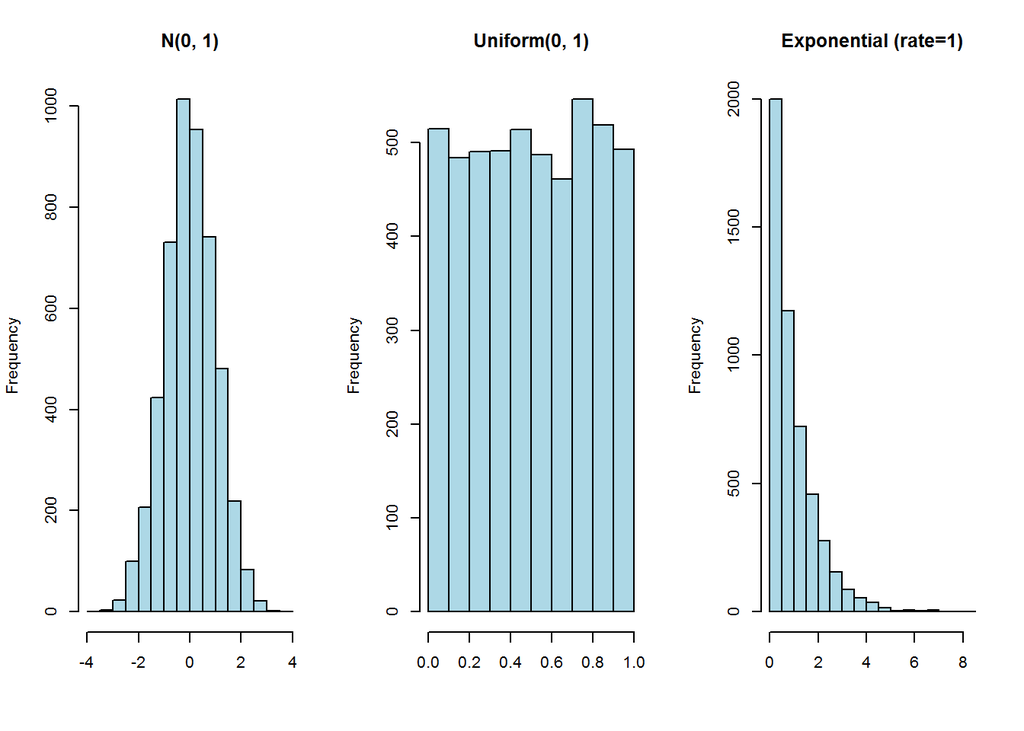

```
## $x
## $x[[1]]
##      Min.   1st Qu.    Median      Mean   3rd Qu.      Max.
## -3.711000 -0.637800 -0.000217  0.006543  0.671800  3.633000
##
## $x[[2]]
##      Min.   1st Qu.    Median      Mean   3rd Qu.      Max.
## 0.0001241 0.2518000 0.5012000 0.5028000 0.7566000 0.9999000
##
## $x[[3]]
##    Min. 1st Qu.  Median    Mean 3rd Qu.    Max.
## 0.00001 0.29140 0.68340 0.98260 1.37900 8.46300
##
##
## $main
## $main[[1]]
##    Length     Class      Mode
##         1 character character
##
## $main[[2]]
##    Length     Class      Mode
##         1 character character
##
## $main[[3]]
##    Length     Class      Mode
##         1 character character
```

```r
# Chaining is available by way of the %>% operator
pretty_titles <- c("N(0, 1)", "Uniform(0, 1)", "Exponential (rate=1)")
set.seed(1607120947)
x <- invoke_map(list(rnorm, runif, rexp), n=5000)
foo <- function(x) { map(x, .f=summary) }
par(mfrow=c(1, 3))
pwalk(list(x=x, main=pretty_titles), .f=hist, xlab="", col="light blue") %>% map(.f=foo)
```

```r
par(mfrow=c(1, 1))
```

#### *Writing Robust Functions*

There are two potentially desirable behaviors with functions:

- Relaxed (default R approach) - make reasonable guesses about what you mean, which is particularly useful for interactive analyses
- Robust (programming) - strict functions that throw errors rather than guessing in light of uncertainty

As a best practice, R functions that will be used for programming (as opposed to interactive command line work) should be written in a robust manner. Three standard problems should be avoided/mitigated:

- Type-unstable - may return a vector one time, and a list the next
- Non-standard evaluation - can use succinct API, but can introduce ambiguity
- Hidden arguments - dependence on global functions/environments

There are several methods available for throwing errors within an R function:

- stopifnot(expression) will stop and throw an error unless expression is TRUE
- if (expression) { stop(“Error”, call.=FALSE) }
- if (expression) { stop(" ‘x’ should be a character vector“, call.=FALSE) }
  - call.=FALSE means that the call to the function should not be shown (???) - Hadley recommends this

One example that commonly creates surprises is the [,] operator for extraction. Adding [ , , drop=FALSE] ensures that you will still have what you passed (e.g., a matrix or data frame) rather than conversion of achunk of data to a vector.

Another common source of error is sapply() which will return a vector when it can and a list otherwise. The map() and map_typ() functions in purrr are designed to be type-stable; if the output is not as expected, they will error out.

Non-standard evaluations take advantage of the existence of something else (e.g., a variable in the parent environment that has not been passed). This can cause confusion and improper results.

- subset(mtcars, disp > 400) takes advantage of disp being an element of mtcars; disp would crash if called outside subset
- This can cause problems when it is embedded inside a function
- ggplot and dplyr frequently have these behaviors also
  - The risk is that you can also put variables from the global environment in to the same call

Pure functions have the key properties that 1) their output depends only on their inputs, and 2) they do not impact the outside world other than by way of their return value. Specifically, the function should not depend on how the user has configured their global options as shown in options(), nor should it modify those options() settings upon return of control to the parent environment.

A few examples are shown below:

```r
# Throwing errors to stop a function (cannot actually run these!)
# stopifnot(FALSE)
# if (FALSE) { stop("Error: ", call.=FALSE) }
# if (FALSE) { stop("Error: This condition needed to be set as TRUE", call.=FALSE) }

# Behavior of [,] and [,,drop=FALSE]
mtxTest <- matrix(data=1:9, nrow=3, byrow=TRUE)
class(mtxTest)
```

```
## [1] "matrix"
```

```r
mtxTest[1, ]
```

```
## [1] 1 2 3
```

```r
class(mtxTest[1, ])
```

```
## [1] "integer"
```

```r
mtxTest[1, , drop=FALSE]
```

```
##      [,1] [,2] [,3]
## [1,]    1    2    3
```

```r
class(mtxTest[1, , drop=FALSE])
```

```
## [1] "matrix"
```

```r
# Behavior of sapply() - may not get what you are expecting
foo <- function(x) { x^2 }
sapply(1:5, FUN=foo)
```

```
## [1]  1  4  9 16 25
```

```r
class(sapply(1:5, FUN=foo))
```

```
## [1] "numeric"
```

```r
sapply(c(1, list(1.5, 2, 2.5), 3, 4, 5), FUN=foo)
```

```
## [1]  1.00  2.25  4.00  6.25  9.00 16.00 25.00
```

```r
class(sapply(c(1, list(1.5, 2, 2.5), 3, 4, 5), FUN=foo))
```

```
## [1] "numeric"
```

```r
sapply(list(1, c(1.5, 2, 2.5), 3, 4, 5), FUN=foo)
```

```
## [[1]]
## [1] 1
##
## [[2]]
## [1] 2.25 4.00 6.25
##
## [[3]]
## [1] 9
##
## [[4]]
## [1] 16
##
## [[5]]
## [1] 25
```

```r
class(sapply(list(1, c(1.5, 2, 2.5), 3, 4, 5), FUN=foo))
```

```
## [1] "list"
```

This was a very enjoyable and instructive course.

### *Importing Data in to R*

This course provides an overview of loading data in to R from five main sources:

- Flat files
- Excel files
- Statistical software
- Databases
- Web data

#### *Reading Flat Files*

At the most basic level, the utlis library easily handles reading most types of flat files:

- read.table(file, header=FALSE, sep=“”, stringsAsFactors=default.stringsAsFactors(), )
- read.csv(file, header = TRUE, sep = “,”, quote = “"”, dec = “.”, fill = TRUE, comment.char = “”, …)
- read.delim(file, header = TRUE, sep = “”, quote = “"”, dec = “.”, fill = TRUE, comment.char = “”, …)

There are also European equivalents in case the decimal needs to be set as “,” to read in the file:

- read.csv2(file, header = TRUE, sep = “;”, quote = “"”, dec = “,”, fill = TRUE, comment.char = “”, …)
- read.delim2(file, header = TRUE, sep = “”, quote = “"”, dec = “,”, fill = TRUE, comment.char = “”, …)

The file.path() command is a nice way to put together file paths. It is more or less equivalent to paste(, sep=“/”), but with the benefit that sep is machine/operating-system dependent, so it may be easier to use across platforms.

Further, there is the option to use colClasses() to specify the type in each column, with NULL meaning do not import. Abbreviations can be used for these as well:

```r
# colClasses (relevant abbreviations)
R.utils::colClasses("-?cdfilnrzDP")
```

```
##  [1] "NULL"      "NA"        "character" "double"    "factor"
##  [6] "integer"   "logical"   "numeric"   "raw"       "complex"
## [11] "Date"      "POSIXct"
```

```r
# file.path example
file.path("..", "myplot.pdf")
```

```
## [1] "../myplot.pdf"
```

```r
# Key documentation for reading flat files
#
# read.table(file, header = FALSE, sep = "", quote = "\"'",
#            dec = ".", numerals = c("allow.loss", "warn.loss", "no.loss"),
#            row.names, col.names, as.is = !stringsAsFactors,
#            na.strings = "NA", colClasses = NA, nrows = -1,
#            skip = 0, check.names = TRUE, fill = !blank.lines.skip,
#            strip.white = FALSE, blank.lines.skip = TRUE,
#            comment.char = "#",
#            allowEscapes = FALSE, flush = FALSE,
#            stringsAsFactors = default.stringsAsFactors(),
#            fileEncoding = "", encoding = "unknown", text, skipNul = FALSE)
#
# read.csv(file, header = TRUE, sep = ",", quote = "\"",
#          dec = ".", fill = TRUE, comment.char = "", ...)
#
# read.csv2(file, header = TRUE, sep = ";", quote = "\"",
#           dec = ",", fill = TRUE, comment.char = "", ...)
#
# read.delim(file, header = TRUE, sep = "\t", quote = "\"",
#            dec = ".", fill = TRUE, comment.char = "", ...)
#
# read.delim2(file, header = TRUE, sep = "\t", quote = "\"",
#             dec = ",", fill = TRUE, comment.char = "", ...)
```

There are also two libraries that can be especially helpful for reading in flat files - readr and data.table.

- readr::read_delim() handles many data types
- readr::read_delim(file, delim=“,”) will read a CSV
  - assumes col_names=TRUE (eq to header=TRUE)
  - assumes col_types=NULL (imputed from first 100 rows, side effect - no need for stringAsFactors = FALSE)
- col_types can use short type, where c=character, d=double (numeric), i=integer, l=logical (boolean), _=skip
  - col_names = FALSE means make your own
  - col_names = c() means here are the column names you should use
- skip=
- n_max=
- read_csv() is for CSV
- read_tsv is for tab-separated values
- data.table() is designed for speed
  - data.table::fread() is for fast reading
  - The fread() automatically handles the column names and also infers the column separators
  - This is a faster, more convenients, and easier to customize version of read.table()
- Wrappers for the readr() function
  - fac <- col_factor(levels = c(“Beef”, “Meat”, “Poultry”))
  - int <- col_integer()
  - hotdogsFactor <- read_tsv(“hotdogs.txt”,  
    col_names = c(“type”, “calories”, “sodium”), col_types = list(fac, int, int) )

#### *Reading Excel Files*

Further, the library(readxl) is handy for loading Excel sheets:

- readxl::excel_sheets() will list the sheets
  - excel_sheets(path)
- readxl::read_excel() will read in a specific sheet
  - read_excel(path, sheet = 1, col_names = TRUE, col_types = NULL, na = “”, skip=0)
    - col_names: Either TRUE to use the first row as column names, FALSE to number columns sequentially from X1 to Xn, or a character vector giving a name for each column
    - col_types: Either NULL to guess from the spreadsheet or a character vector containing “blank”, “numeric”, “date” or “text”
- lapply(excel_sheets(myXLS), FUN=read_excel, path=myXLS) provide all data from all sheets in a list

#### *Reading Statistical Software Files*

R can also load files from common statistical software such as SAS, STATA, SPSS, and MATLAB/Octave. The packages haven() by Wickham and foreign() by the R core team are two common examples. The R.matlab() allows for reading to/from MATLAB/Octave:

The library(haven) contains wrappers to the ReadStat package, a C library by Evan Miller, for reading files from SAS, STATA, and SPSS:

- read_sas(filename)
- read_stata(filename)
- read_dta(filename)
  - as_factor(R_column) will help if the type is “labelled”
  - as.character(as_factor(R_column)) will turn it back to a character vector
- read_spss(filename) which is a wrapper to read_por() and read_sav()

The library(foreign) can read/write all types of foreign formats, with some caveats:

- Only SAS libraries (.xport) can be read in; seems quite a drawback to not be able to read SAS files!
- read.dta(file, convert.factors = TRUE, convert.dates=TRUE, missing.type=FALSE)
- read.spss(file, use.value.labels = TRUE, to.data.frame = FALSE)

Finally, the R.matlab() library is available for reading/writing MATLAB/Octave files. Per the help file:

- Methods readMat() and writeMat() for reading and writing MAT files. For user with MATLAB v6 or newer installed (either locally or on a remote host), the package also provides methods for controlling MATLAB (trademark) via R and sending and retrieving data between R and MATLAB.
- In brief, this package provides a one-directional interface from R to MATLAB, with communication taking place via a TCP/IP connection and with data transferred either through another connection or via the file system. On the MATLAB side, the TCP/IP connection is handled by a small Java add-on.
- The methods for reading and writing MAT files are stable. The R to MATLAB interface, that is the Matlab class, is less prioritized and should be considered a beta version.
- readMat(con, maxLength=NULL, fixNames=TRUE, drop=c(“singletonLists”), sparseMatrixClass=c(“Matrix”, “SparseM”, “matrix”), verbose=FALSE, …)
  - Returns a named list structure containing all variables in the MAT file structure.
- writeMat(con, …, matVersion=“5”, onWrite=NULL, verbose=FALSE)
  - con: Binary connection to which the MAT file structure should be written to. A string is interpreted as filename, which then will be opened (and closed afterwards).
  - …: Named variables to be written where the names must be unique.

#### *Reading Relational DB Files*

Relational databases in R (DBMS tend to use SQL for queries), including libraries:

- RMySQL
- RPostgresSQL
- ROracle
- RSQLite

Conventions are specified in DBI; see library(DBI):

- dbConnect(drv, …)
- drv

Create the connection as “con” (or whatever) and then use that elsewhere:

- dbListTables(con) # What tables are in this
- dbReadTable(con, tablename)

When finished, dbDisconnect(con) as a courtesy so as to not tie up resources.

SQL queries from inside R - per previous, library(DBI) and then create the connection “con”:

- dbGetQuery(con, valid_SQL_code)
  - Appears that " is an escape character to use quotes inside quotes
  - dbGetQuery(con, “SELECT name FROM employees WHERE started_at > "2012-09-01"”)
  - dbGetQuery(con, “SELECT * FROM products WHERE contract=1”)
- res <- dbSendQuery(con, validSQLcode) # If instead you want to grab only chunks of records
  - dbFetch(res) # Can specify chunking, such as dbFetch(res, n=1) for one line at a time
  - dbHasCompleted(res) # see whether it is done
    - while(!dbHasCompleted(res)) { chunk <- dbFetch(res, n=1); print(chunk) }
  - dbClearResult(res)

For example, using “./SQLforDataCampRMD_v01.db”, run a few SQL commands:

```r
# uses libraries DBI for the connection and RSQLite to interface with SQLite Browser on my machine
con <- DBI::dbConnect(RSQLite::SQLite(), "SQLforDataCampRMD_v01.db")

# List the tables, and drop dummy if it already exists
DBI::dbListTables(con)
```

```
## [1] "dummy"
```

```r
DBI::dbGetQuery(con, "DROP TABLE IF EXISTS dummy")

# Create blank table
DBI::dbListTables(con)
```

```
## character(0)
```

```r
DBI::dbGetQuery(con, "CREATE TABLE IF NOT EXISTS dummy (id PRIMARY KEY, name CHAR)")
DBI::dbGetQuery(con, "INSERT OR IGNORE INTO dummy (id, name) VALUES (1, 'Amy')")
DBI::dbGetQuery(con, "INSERT OR IGNORE INTO dummy (id, name) VALUES (2, 'Bill')")
DBI::dbGetQuery(con, "INSERT OR IGNORE INTO dummy (id, name) VALUES (2, 'Jen')") # Should do nothing
DBI::dbGetQuery(con, "SELECT * FROM dummy")
```

```
##   id name
## 1  1  Amy
## 2  2 Bill
```

```r
DBI::dbListTables(con)
```

```
## [1] "dummy"
```

```r
# Can continue passing SQL commands back and forth as needed

# Close the connection
DBI::dbDisconnect(con)
```

```
## [1] TRUE
```

#### *Reading Web Data*

Many of the R read-in libraries already work well with web data. For example, read.csv(“mywebsite.com”, stringAsFactors=FALSE) will read a CSV right off the internet. Further, there are options for:

- download.file(url, dest_path) # Reproducibility advantages over right-click and save
- library(httr) by Hadley Wickham, including GET() and content()

The jsonlite library is good for working with JSON:

- fromJSON(url) will create a named R list (often creates a data frame also)
  - JSON objects are name:value pairs
  - JSON arrays convert to vectors
  - JSON can also created nested arrays
- toJSON()

Prettify adds indentation to a JSON string; minify removes all indentation/whitespace:

- prettify() prettify(txt, indent = 4)
- minify() minify(txt)

```r
jsonLoc <- file.path("../../..", "PythonDirectory", "UMModule04", "roster_data.json")
jsonData <- jsonlite::fromJSON(jsonLoc)
str(jsonData)
```

```
##  chr [1:379, 1:3] "Calvin" "Wilson" "Emi" "Rosina" "Sylvie" ...
```

```r
head(jsonData)
```

```
##      [,1]        [,2]    [,3]
## [1,] "Calvin"    "si110" "1"
## [2,] "Wilson"    "si110" "0"
## [3,] "Emi"       "si110" "0"
## [4,] "Rosina"    "si110" "0"
## [5,] "Sylvie"    "si110" "0"
## [6,] "Katarzyna" "si110" "0"
```

### *Cleaning Data in R*

The general analysis pipeline is Collect -> Clean -> Analyze -> Report. Cleaning is needed so the raw data can work with more traditional tools (e.g., packages in Python or R). 50% - 80% of time is spent in the Collect/Clean realm, even though this is not the most exciting (and thus taught) part of data analysis. There are generally three stages of data cleaning: Explore -> Tidy -> Prepare

Exploring the Data:

- class()
- dim()
- names() # column names
- str()
- dplyr::glimpse() # a nicer version of str()
- summary()

Viewing the Data:

- head(file, n=6)
- tail(file, n=6)
- hist(variable)
- plot(x, y)
- print() # not recommended for larger datasets

Tidy data - Wickham 2014, Principles of Tidy Data:

- Each row should be an observation
- Each column should be a variable (attribute)
- Column headers should not be variables; e.g., eye color should be a single column, not many columns of 0/1
- Each intersection should be a value (intersection of the observation and attribute)
- Only one type of observational unit (e.g., each row is a person) per table

The principles of tidy data can be implemented using library(tidyr):

- tidyr::gather(data, key, value, …, na.rm = FALSE, convert = FALSE, factor_key = FALSE) # gather the data in to key-value pairs
  - key, value Names of key and value columns to create in output.
  - … Specification of columns to gather. Use bare variable names. Select all variables between x and z with x:z, exclude y with -y. For more options, see the select documentation.
- tidyr::spread(data, key, value, fill = NA, convert = FALSE, drop = TRUE) # spread the key-value pairs in to columns
  - key The bare (unquoted) name of the column whose values will be used as column headings.
  - value The bare (unquoted) name of the column whose values will populate the cells.
  - fill If set, missing values will be replaced with this value. Note that there are two types of missing in the input: explicit missing values (i.e. NA), and implicit missings, rows that simply aren’t present. Both types of missing value will be replaced by fill.
- tidyr::separate(data, col, into, sep = “[^[:alnum:]]+”, remove = TRUE, convert = FALSE, extra = “warn”, fill = “warn”, …)
  - col Bare column name.
  - into Names of new variables to create as character vector.
  - sep Separator between columns. If character, is interpreted as a regular expression. The default value is a regular expression that matches any sequence of non-alphanumeric values. If numeric, interpreted as positions to split at. Positive values start at 1 at the far-left of the string; negative value start at -1 at the far-right of the string. The length of sep should be one less than into.
- tidyr::unite(data, col, …, sep = “_“, remove = TRUE)
  - col (Bare) name of column to add
  - … Specification of columns to unite. Use bare variable names. Select all variables between x and z with x:z, exclude y with -y. For more options, see the select documentation.
  - sep Separator to use between values.

Common symptoms of messy data include:

- Column headers are values rather than variable names – use tidyr::gather()
- Variables stored in both rows and columns – use tidyr::spread()
- Multiple variables are stored in a single column – use tidyr::separate()
- Singe type of observational unit (e.g., people) stored in 2+ tables
- Multiple types of observational units (e.g., people and pets) stored in a single table

Example code includes:

```r
# tidyr::gather()
stocks <- data.frame(time = as.Date('2009-01-01') + 0:4,
                     X = rnorm(5, 0, 1), Y = rnorm(5, 0, 2), Z = rnorm(5, 0, 4)
                     )
stocks
```

```
##         time           X          Y         Z
## 1 2009-01-01  1.64736472 -0.1020457 -8.074672
## 2 2009-01-02  0.32981671 -0.2377234  7.617473
## 3 2009-01-03  0.05010405 -0.7091054 -9.770047
## 4 2009-01-04  0.41187479  1.1899260 -1.655071
## 5 2009-01-05 -2.20625659 -1.1299452  1.615068
```

```r
# will create new columns stock (each of X, Y, Z) and price (the values that had been in X, Y, and Z),
# while not gathering the time variable; final table will be time-stock-price
stockGather <- tidyr::gather(stocks, stock, price, -time)
stockGather
```

```
##          time stock       price
## 1  2009-01-01     X  1.64736472
## 2  2009-01-02     X  0.32981671
## 3  2009-01-03     X  0.05010405
## 4  2009-01-04     X  0.41187479
## 5  2009-01-05     X -2.20625659
## 6  2009-01-01     Y -0.10204566
## 7  2009-01-02     Y -0.23772338
## 8  2009-01-03     Y -0.70910541
## 9  2009-01-04     Y  1.18992602
## 10 2009-01-05     Y -1.12994523
## 11 2009-01-01     Z -8.07467238
## 12 2009-01-02     Z  7.61747283
## 13 2009-01-03     Z -9.77004663
## 14 2009-01-04     Z -1.65507149
## 15 2009-01-05     Z  1.61506772
```

```r
# tidyr::spread()
tidyr::spread(stockGather, stock, price)
```

```
##         time           X          Y         Z
## 1 2009-01-01  1.64736472 -0.1020457 -8.074672
## 2 2009-01-02  0.32981671 -0.2377234  7.617473
## 3 2009-01-03  0.05010405 -0.7091054 -9.770047
## 4 2009-01-04  0.41187479  1.1899260 -1.655071
## 5 2009-01-05 -2.20625659 -1.1299452  1.615068
```

```r
# TRUE (this fully reverses what the gather function has done)
identical(tidyr::spread(stockGather, stock, price), stocks)
```

```
## [1] TRUE
```

```r
# tidyr::separate()
df <- data.frame(x = c(NA, "a.b", "a.d", "b.c"))
df
```

```
##      x
## 1 <NA>
## 2  a.b
## 3  a.d
## 4  b.c
```

```r
# by default, the splits occur on anything that is not alphanumeric,
# so you get column A as whatever is before the dot and column B as whatever is after the dot
dfSep <- tidyr::separate(df, x, c("A", "B"))
dfSep
```

```
##      A    B
## 1 <NA> <NA>
## 2    a    b
## 3    a    d
## 4    b    c
```

```r
# tidyr::unite()
tidyr::unite(dfSep, united, c(A, B), sep="")
```

```
##   united
## 1   NANA
## 2     ab
## 3     ad
## 4     bc
```

```r
is.na(dfSep) # caution . . .
```

```
##       A     B
## 1  TRUE  TRUE
## 2 FALSE FALSE
## 3 FALSE FALSE
## 4 FALSE FALSE
```

```r
is.na(tidyr::unite(dfSep, united, c(A, B), sep="")) # caution . . .
```

```
##   united
## 1  FALSE
## 2  FALSE
## 3  FALSE
## 4  FALSE
```

- The library(lubridate) can be helpful for coercing strings to dates
  - ymd() # coerces a character string that is in year-month-day originally
  - mdy() # coerces a character string that is in month-day-year originally
  - hms() # coerces a character string that is in hours-minutes-seconds originally
  - ymd_hms() # coerces a character string that is in year-month-day-hours-minutes-seconds
- The library(stringr) can be helpful for working with strings
  - stringr::str_trim() # trails the leading and trailing white space
  - stringr::str_pad(char, width, side, pad) # adds characters in place of white space at the start/end
  - stringr::str_detect(inVector, searchTerm) # is searchTerm in each iterm of vector (boolean, same length as inVector)
  - stringr::str_replace(inVector, searchTerm, replaceTerm) # searchTerm will be replaced by replaceTerm in each iterm of vector (output same length/type as inVector)
    - social_df$status <- str_replace(social_df$status, “^$”, NA) # Nice way to make the blanks in to NA
- The tolower() and toupper() commands can be very useful also
- Missing and special values
  - May be randomly missing, but very dangerous to assume!
  - In R, these are NA
    - Excel may have #N/A
    - SPSS and SAS may have .
    - Sometimes just shows up as a missing string
  - Inf is for infinite
  - NaN is for not a number
- Finding these special values
  - is.na()
  - any(is.na())
  - sum(is.na())
  - summary() # will tell the number of NA
  - complete.cases() # TRUE is the entire row is non-NA; FALSE otherwise
  - na.omit() # equivalent to x[complete.cases(x), ]

Example code includes:

```r
# lubridate::ymd()
lubridate::ymd("160720")
```

```
## [1] "2016-07-20 UTC"
```

```r
lubridate::ymd("2016-7-20")
```

```
## [1] "2016-07-20 UTC"
```

```r
lubridate::ymd("16jul20")
```

```
## [1] "2016-07-20 UTC"
```

```r
lubridate::ymd("16/07/20")
```

```
## [1] "2016-07-20 UTC"
```

```r
# lubridate::hms()
lubridate::hms("07h15:00")
```

```
## [1] "7H 15M 0S"
```

```r
lubridate::hms("17 hours, 15 minutes 00 seconds")
```

```
## [1] "17H 15M 0S"
```

```r
lubridate::hms("07-15-00")
```

```
## [1] "7H 15M 0S"
```

```r
# From ?stringr::str_detect
#
# str_detect(string, pattern)
#   string  Input vector. Either a character vector, or something coercible to one.
#   pattern Pattern to look for.  The default interpretation is a regular expression, as described in stringi-search-regex. Control options with regex().  Match a fixed string (i.e. by comparing only bytes), using fixed(x). This is fast, but approximate. Generally, for matching human text, you'll want coll(x) which respects character matching rules for the specified locale.  Match character, word, line and sentence boundaries with boundary(). An empty pattern, "", is equivalent to boundary("character").
#

fruit <- c("apple", "banana", "pear", "pinapple")

stringr::str_detect(fruit, "a")
```

```
## [1] TRUE TRUE TRUE TRUE
```

```r
stringr::str_detect(fruit, "^a")
```

```
## [1]  TRUE FALSE FALSE FALSE
```

```r
stringr::str_detect(fruit, "a$")
```

```
## [1] FALSE  TRUE FALSE FALSE
```

```r
stringr::str_detect(fruit, "b")
```

```
## [1] FALSE  TRUE FALSE FALSE
```

```r
stringr::str_detect(fruit, "[aeiou]")
```

```
## [1] TRUE TRUE TRUE TRUE
```

```r
# Also vectorised over pattern
stringr::str_detect("aecfg", letters)
```

```
##  [1]  TRUE FALSE  TRUE FALSE  TRUE  TRUE  TRUE FALSE FALSE FALSE FALSE
## [12] FALSE FALSE FALSE FALSE FALSE FALSE FALSE FALSE FALSE FALSE FALSE
## [23] FALSE FALSE FALSE FALSE
```

```r
# From ?stringr::str_replace
#
# str_replace(string, pattern, replacement)
# str_replace_all(string, pattern, replacement)
#   string  Input vector. Either a character vector, or something coercible to one.
#   pattern, replacement    Supply separate pattern and replacement strings to vectorise over the patterns. References of the form \1, \2 will be replaced with the contents of the respective matched group (created by ()) within the pattern.  For str_replace_all only, you can perform multiple patterns and replacements to each string, by passing a named character to pattern.
#

someNA <- c(letters, "", LETTERS, "")
someNA[someNA==""] <- NA
someNA
```

```
##  [1] "a" "b" "c" "d" "e" "f" "g" "h" "i" "j" "k" "l" "m" "n" "o" "p" "q"
## [18] "r" "s" "t" "u" "v" "w" "x" "y" "z" NA  "A" "B" "C" "D" "E" "F" "G"
## [35] "H" "I" "J" "K" "L" "M" "N" "O" "P" "Q" "R" "S" "T" "U" "V" "W" "X"
## [52] "Y" "Z" NA
```

```r
fruits <- c("one apple", "two pears", "three bananas")
stringr::str_replace(fruits, "[aeiou]", "-")  # Replace FIRST instance
```

```
## [1] "-ne apple"     "tw- pears"     "thr-e bananas"
```

```r
stringr::str_replace_all(fruits, "[aeiou]", "-")  # Replace ALL instances
```

```
## [1] "-n- -ppl-"     "tw- p--rs"     "thr-- b-n-n-s"
```

```r
stringr::str_replace(fruits, "([aeiou])", "\\1\\1\\1")  # Triple up on the first vowel
```

```
## [1] "ooone apple"     "twooo pears"     "threeee bananas"
```

```r
stringr::str_replace(fruits, "[aeiou]", c("1", "2", "3"))  # First vowel to 1, 2, 3 in word 1, 2, 3
```

```
## [1] "1ne apple"     "tw2 pears"     "thr3e bananas"
```

```r
stringr::str_replace(fruits, c("a", "e", "i"), "-")  # First a -> - in word 1, first e -> - in word 2 . . .
```

```
## [1] "one -pple"     "two p-ars"     "three bananas"
```

```r
stringr::str_replace_all(fruits, "([aeiou])", "\\1\\1")  # Double up on all vowels
```

```
## [1] "oonee aapplee"      "twoo peeaars"       "threeee baanaanaas"
```

```r
stringr::str_replace_all(fruits, "[aeiou]", c("1", "2", "3"))  # All vowels to 1, 2, 3, in word 1, 2, 3
```

```
## [1] "1n1 1ppl1"     "tw2 p22rs"     "thr33 b3n3n3s"
```

```r
stringr::str_replace_all(fruits, c("a", "e", "i"), "-")  # All a -> - in word 1, . . .
```

```
## [1] "one -pple"     "two p-ars"     "three bananas"
```

Further, the outline from the weather gathering data cleaning challenge is noted:

- The weather data tidying challenge
  - Historical weather data from Boston
    - 12 months beginning December 2014
    - Columns are values (X1 means day 1, X2 means day 2, etc.), while measure (Max, Min, etc.) should be variables
    - Variables coded incorrectly
    - Missing and extreme values
    - Etc.
- STEP 1: UNDERSTAND STRUCTURE
  - class(), dim(), names(), str(), dplyr::glimpse(), summary()
- STEP 2: LOOK AT DATA
  - head(), tail(), print(), hist(), plot()
- STEP 3: TIDY DATA
  - gather(), spread(), separate()
- STEP 4: CONVERT TYPES
  - lubridate() and variants, as.character() and variants, stringr() and variants, tidyr::unite()
- STEP 5: MANAGE MISSING and EXTREME (OUTLIER) VALUES
  - is.na(), sum(is.na()), any(is.na()), which(is.na())
  - which(a, arr.ind=TRUE) returns a little matrix of rows and columns - nice!

### *Data Manipulation (dplyr)*

The library(dplyr) is a grammar of data manipulation. It is written in C++ so you get the speed of C with the convenience of R. It is in essence the data frame to data frame portion of plyr (plyr was the original Split-Apply-Combine). May want to look in to count, transmute, and other verbs added post this summary.

The examples use data(hflights) from library(hflights):

```r
library(dplyr)
library(hflights)
data(hflights)
head(hflights)
```

```
##      Year Month DayofMonth DayOfWeek DepTime ArrTime UniqueCarrier
## 5424 2011     1          1         6    1400    1500            AA
## 5425 2011     1          2         7    1401    1501            AA
## 5426 2011     1          3         1    1352    1502            AA
## 5427 2011     1          4         2    1403    1513            AA
## 5428 2011     1          5         3    1405    1507            AA
## 5429 2011     1          6         4    1359    1503            AA
##      FlightNum TailNum ActualElapsedTime AirTime ArrDelay DepDelay Origin
## 5424       428  N576AA                60      40      -10        0    IAH
## 5425       428  N557AA                60      45       -9        1    IAH
## 5426       428  N541AA                70      48       -8       -8    IAH
## 5427       428  N403AA                70      39        3        3    IAH
## 5428       428  N492AA                62      44       -3        5    IAH
## 5429       428  N262AA                64      45       -7       -1    IAH
##      Dest Distance TaxiIn TaxiOut Cancelled CancellationCode Diverted
## 5424  DFW      224      7      13         0                         0
## 5425  DFW      224      6       9         0                         0
## 5426  DFW      224      5      17         0                         0
## 5427  DFW      224      9      22         0                         0
## 5428  DFW      224      9       9         0                         0
## 5429  DFW      224      6      13         0                         0
```

```r
summary(hflights)
```

```
##       Year          Month          DayofMonth      DayOfWeek
##  Min.   :2011   Min.   : 1.000   Min.   : 1.00   Min.   :1.000
##  1st Qu.:2011   1st Qu.: 4.000   1st Qu.: 8.00   1st Qu.:2.000
##  Median :2011   Median : 7.000   Median :16.00   Median :4.000
##  Mean   :2011   Mean   : 6.514   Mean   :15.74   Mean   :3.948
##  3rd Qu.:2011   3rd Qu.: 9.000   3rd Qu.:23.00   3rd Qu.:6.000
##  Max.   :2011   Max.   :12.000   Max.   :31.00   Max.   :7.000
##
##     DepTime        ArrTime     UniqueCarrier        FlightNum
##  Min.   :   1   Min.   :   1   Length:227496      Min.   :   1
##  1st Qu.:1021   1st Qu.:1215   Class :character   1st Qu.: 855
##  Median :1416   Median :1617   Mode  :character   Median :1696
##  Mean   :1396   Mean   :1578                      Mean   :1962
##  3rd Qu.:1801   3rd Qu.:1953                      3rd Qu.:2755
##  Max.   :2400   Max.   :2400                      Max.   :7290
##  NA's   :2905   NA's   :3066
##    TailNum          ActualElapsedTime    AirTime         ArrDelay
##  Length:227496      Min.   : 34.0     Min.   : 11.0   Min.   :-70.000
##  Class :character   1st Qu.: 77.0     1st Qu.: 58.0   1st Qu.: -8.000
##  Mode  :character   Median :128.0     Median :107.0   Median :  0.000
##                     Mean   :129.3     Mean   :108.1   Mean   :  7.094
##                     3rd Qu.:165.0     3rd Qu.:141.0   3rd Qu.: 11.000
##                     Max.   :575.0     Max.   :549.0   Max.   :978.000
##                     NA's   :3622      NA's   :3622    NA's   :3622
##     DepDelay          Origin              Dest              Distance
##  Min.   :-33.000   Length:227496      Length:227496      Min.   :  79.0
##  1st Qu.: -3.000   Class :character   Class :character   1st Qu.: 376.0
##  Median :  0.000   Mode  :character   Mode  :character   Median : 809.0
##  Mean   :  9.445                                         Mean   : 787.8
##  3rd Qu.:  9.000                                         3rd Qu.:1042.0
##  Max.   :981.000                                         Max.   :3904.0
##  NA's   :2905
##      TaxiIn           TaxiOut         Cancelled       CancellationCode
##  Min.   :  1.000   Min.   :  1.00   Min.   :0.00000   Length:227496
##  1st Qu.:  4.000   1st Qu.: 10.00   1st Qu.:0.00000   Class :character
##  Median :  5.000   Median : 14.00   Median :0.00000   Mode  :character
##  Mean   :  6.099   Mean   : 15.09   Mean   :0.01307
##  3rd Qu.:  7.000   3rd Qu.: 18.00   3rd Qu.:0.00000
##  Max.   :165.000   Max.   :163.00   Max.   :1.00000
##  NA's   :3066      NA's   :2947
##     Diverted
##  Min.   :0.000000
##  1st Qu.:0.000000
##  Median :0.000000
##  Mean   :0.002853
##  3rd Qu.:0.000000
##  Max.   :1.000000
##
```

The “tbl” is a special type of data frame, which is very helpful for printing:

- tbl_df(myFrame) # can store or whatever - will be a tbl_df, tbl, and data.frame
  - Display is modified to fit the window display - will scale with the window
- glimpse(myFrame) # lets you see al the variables and first few records for each (sort of like str)
- as.data.frame(tbl_df(myFrame)) # this will be the data frame
  - identical(as.data.frame(tbl_df(hflights)), hflights) # FALSE
  - sum(is.na(as.data.frame(tbl_df(hflights))) != is.na(hflights)) # 0
  - sum(as.data.frame(tbl_df(hflights)) != hflights, na.rm=TRUE) # 0

An interesting way to do a lookup table:

- two <- c(“AA”, “AS”)
- lut <- c(“AA” = “American”, “AS” = “Alaska”, “B6” = “JetBlue”)
- two <- lut[two]
- two

See for example:

```r
lut <- c("AA" = "American", "AS" = "Alaska", "B6" = "JetBlue", "CO" = "Continental",
         "DL" = "Delta", "OO" = "SkyWest", "UA" = "United", "US" = "US_Airways",
         "WN" = "Southwest", "EV" = "Atlantic_Southeast", "F9" = "Frontier",
         "FL" = "AirTran", "MQ" = "American_Eagle", "XE" = "ExpressJet", "YV" = "Mesa"
         )
hflights$Carrier <- lut[hflights$UniqueCarrier]
glimpse(hflights)
```

```
## Observations: 227,496
## Variables: 22
## $ Year              (int) 2011, 2011, 2011, 2011, 2011, 2011, 2011, 20...
## $ Month             (int) 1, 1, 1, 1, 1, 1, 1, 1, 1, 1, 1, 1, 1, 1, 1,...
## $ DayofMonth        (int) 1, 2, 3, 4, 5, 6, 7, 8, 9, 10, 11, 12, 13, 1...
## $ DayOfWeek         (int) 6, 7, 1, 2, 3, 4, 5, 6, 7, 1, 2, 3, 4, 5, 6,...
## $ DepTime           (int) 1400, 1401, 1352, 1403, 1405, 1359, 1359, 13...
## $ ArrTime           (int) 1500, 1501, 1502, 1513, 1507, 1503, 1509, 14...
## $ UniqueCarrier     (chr) "AA", "AA", "AA", "AA", "AA", "AA", "AA", "A...
## $ FlightNum         (int) 428, 428, 428, 428, 428, 428, 428, 428, 428,...
## $ TailNum           (chr) "N576AA", "N557AA", "N541AA", "N403AA", "N49...
## $ ActualElapsedTime (int) 60, 60, 70, 70, 62, 64, 70, 59, 71, 70, 70, ...
## $ AirTime           (int) 40, 45, 48, 39, 44, 45, 43, 40, 41, 45, 42, ...
## $ ArrDelay          (int) -10, -9, -8, 3, -3, -7, -1, -16, 44, 43, 29,...
## $ DepDelay          (int) 0, 1, -8, 3, 5, -1, -1, -5, 43, 43, 29, 19, ...
## $ Origin            (chr) "IAH", "IAH", "IAH", "IAH", "IAH", "IAH", "I...
## $ Dest              (chr) "DFW", "DFW", "DFW", "DFW", "DFW", "DFW", "D...
## $ Distance          (int) 224, 224, 224, 224, 224, 224, 224, 224, 224,...
## $ TaxiIn            (int) 7, 6, 5, 9, 9, 6, 12, 7, 8, 6, 8, 4, 6, 5, 6...
## $ TaxiOut           (int) 13, 9, 17, 22, 9, 13, 15, 12, 22, 19, 20, 11...
## $ Cancelled         (int) 0, 0, 0, 0, 0, 0, 0, 0, 0, 0, 0, 0, 0, 0, 0,...
## $ CancellationCode  (chr) "", "", "", "", "", "", "", "", "", "", "", ...
## $ Diverted          (int) 0, 0, 0, 0, 0, 0, 0, 0, 0, 0, 0, 0, 0, 0, 0,...
## $ Carrier           (chr) "American", "American", "American", "America...
```

There are five main verbs in dplyr:

- select - subset of columns from a dataset
  - select(df, . . . ) where . . . Are the columns to be kept
  - starts_with(“X”): every name that starts with “X”,
  - ends_with(“X”): every name that ends with “X”,
  - contains(“X”): every name that contains “X”,
  - matches(“X”): every name that matches “X”, where “X” can be a regular expression,
  - num_range(“x”, 1:5): the variables named x01, x02, x03, x04 and x05,
  - one_of(x): every name that appears in x, which should be a character vector.
  - filter - subset of rows from a dataset
    - filter(df, .) where … are 1+ logical tests (so make sure to use == or all.equal() or the like)
- arrange - reorder rows in a dataset
  - arrange(df, .) where . are the colunns to reorder by
- mutate - create new columns in a dataset
  - mutate(df, .) where each . is a formula for a new variable to be created
- summarize - create summary statistics for a dataset
  - summarize(df, .) where each . is a formula like newVar = thisEquation
    - only aggregate functions (vector as input, single number as output) should be used
  - dplyr adds several additional aggregate functions such as first, last, nth, n, n_distinct
    - first(x) - The first element of vector x.
    - last(x) - The last element of vector x.
    - nth(x, n) - The nth element of vector x.
    - n() - The number of rows in the data.frame or group of observations that summarise() describes.
    - n_distinct(x) - The number of unique values in vector x.
- In general:
  - select and mutate operate on the variables
  - filter and arrange operate on the observations
  - summarize operates on groups of observations
  - All of these are much cleaner if the data are tidy
- There is also the option to use chaining %>% to process multiple commands
  - Especially useful for memory storage and readability
  - The pipe operator (%>%) comes from the magrittr package by Stefan Bache
  - object %>% function(object will go first)
  - c(1, 2, 3) %>% sum() # 6
  - c(1, 2, 3, NA) %>% mean(na.rm=TRUE) # 2

There is also the group_by capability for summaries of sub-groups:

- group_by(df, .) where the . is what to group the data by
  - The magic is when you run summarize() on data with group_by run on it; results will be by group
  - If you have group_by(df, a, b) %>% summarize(timeSum = sum(time)) # all observations by a-b
  - If you have group_by(df, a, b) %>% summarize(timeSum = sum(time)) %>% summarize(timeA = sum(timeSum)) # all observations by a
  - If you have group_by(df, a, b) %>% summarize(timeSum = sum(time)) %>% summarize(timeA = sum(timeSum)) %>% summarize(timeAll = sum(timeA)) # all observations

The dplyr library can also work with databases. It only loads the data that you need, and you do not need to know the relevant SQL code – dplyr writes the SQL code for you.

Basic select and mutate examples include:

```r
data(hflights)

# Make it faster, as well as a prettier printer
hflights <- tbl_df(hflights)
hflights
```

```
## Source: local data frame [227,496 x 21]
##
##     Year Month DayofMonth DayOfWeek DepTime ArrTime UniqueCarrier
##    (int) (int)      (int)     (int)   (int)   (int)         (chr)
## 1   2011     1          1         6    1400    1500            AA
## 2   2011     1          2         7    1401    1501            AA
## 3   2011     1          3         1    1352    1502            AA
## 4   2011     1          4         2    1403    1513            AA
## 5   2011     1          5         3    1405    1507            AA
## 6   2011     1          6         4    1359    1503            AA
## 7   2011     1          7         5    1359    1509            AA
## 8   2011     1          8         6    1355    1454            AA
## 9   2011     1          9         7    1443    1554            AA
## 10  2011     1         10         1    1443    1553            AA
## ..   ...   ...        ...       ...     ...     ...           ...
## Variables not shown: FlightNum (int), TailNum (chr), ActualElapsedTime
##   (int), AirTime (int), ArrDelay (int), DepDelay (int), Origin (chr), Dest
##   (chr), Distance (int), TaxiIn (int), TaxiOut (int), Cancelled (int),
##   CancellationCode (chr), Diverted (int)
```

```r
class(hflights)
```

```
## [1] "tbl_df"     "tbl"        "data.frame"
```

```r
# Select examples
select(hflights, ActualElapsedTime, AirTime, ArrDelay, DepDelay)
```

```
## Source: local data frame [227,496 x 4]
##
##    ActualElapsedTime AirTime ArrDelay DepDelay
##                (int)   (int)    (int)    (int)
## 1                 60      40      -10        0
## 2                 60      45       -9        1
## 3                 70      48       -8       -8
## 4                 70      39        3        3
## 5                 62      44       -3        5
## 6                 64      45       -7       -1
## 7                 70      43       -1       -1
## 8                 59      40      -16       -5
## 9                 71      41       44       43
## 10                70      45       43       43
## ..               ...     ...      ...      ...
```

```r
select(hflights, Origin:Cancelled)
```

```
## Source: local data frame [227,496 x 6]
##
##    Origin  Dest Distance TaxiIn TaxiOut Cancelled
##     (chr) (chr)    (int)  (int)   (int)     (int)
## 1     IAH   DFW      224      7      13         0
## 2     IAH   DFW      224      6       9         0
## 3     IAH   DFW      224      5      17         0
## 4     IAH   DFW      224      9      22         0
## 5     IAH   DFW      224      9       9         0
## 6     IAH   DFW      224      6      13         0
## 7     IAH   DFW      224     12      15         0
## 8     IAH   DFW      224      7      12         0
## 9     IAH   DFW      224      8      22         0
## 10    IAH   DFW      224      6      19         0
## ..    ...   ...      ...    ...     ...       ...
```

```r
select(hflights, Year:DayOfWeek, ArrDelay:Diverted)
```

```
## Source: local data frame [227,496 x 14]
##
##     Year Month DayofMonth DayOfWeek ArrDelay DepDelay Origin  Dest
##    (int) (int)      (int)     (int)    (int)    (int)  (chr) (chr)
## 1   2011     1          1         6      -10        0    IAH   DFW
## 2   2011     1          2         7       -9        1    IAH   DFW
## 3   2011     1          3         1       -8       -8    IAH   DFW
## 4   2011     1          4         2        3        3    IAH   DFW
## 5   2011     1          5         3       -3        5    IAH   DFW
## 6   2011     1          6         4       -7       -1    IAH   DFW
## 7   2011     1          7         5       -1       -1    IAH   DFW
## 8   2011     1          8         6      -16       -5    IAH   DFW
## 9   2011     1          9         7       44       43    IAH   DFW
## 10  2011     1         10         1       43       43    IAH   DFW
## ..   ...   ...        ...       ...      ...      ...    ...   ...
## Variables not shown: Distance (int), TaxiIn (int), TaxiOut (int),
##   Cancelled (int), CancellationCode (chr), Diverted (int)
```

```r
select(hflights, ends_with("Delay"))
```

```
## Source: local data frame [227,496 x 2]
##
##    ArrDelay DepDelay
##       (int)    (int)
## 1       -10        0
## 2        -9        1
## 3        -8       -8
## 4         3        3
## 5        -3        5
## 6        -7       -1
## 7        -1       -1
## 8       -16       -5
## 9        44       43
## 10       43       43
## ..      ...      ...
```

```r
select(hflights, UniqueCarrier, ends_with("Num"), starts_with("Cancel"))
```

```
## Source: local data frame [227,496 x 5]
##
##    UniqueCarrier FlightNum TailNum Cancelled CancellationCode
##            (chr)     (int)   (chr)     (int)            (chr)
## 1             AA       428  N576AA         0
## 2             AA       428  N557AA         0
## 3             AA       428  N541AA         0
## 4             AA       428  N403AA         0
## 5             AA       428  N492AA         0
## 6             AA       428  N262AA         0
## 7             AA       428  N493AA         0
## 8             AA       428  N477AA         0
## 9             AA       428  N476AA         0
## 10            AA       428  N504AA         0
## ..           ...       ...     ...       ...              ...
```

```r
select(hflights, ends_with("Time"), ends_with("Delay"))
```

```
## Source: local data frame [227,496 x 6]
##
##    DepTime ArrTime ActualElapsedTime AirTime ArrDelay DepDelay
##      (int)   (int)             (int)   (int)    (int)    (int)
## 1     1400    1500                60      40      -10        0
## 2     1401    1501                60      45       -9        1
## 3     1352    1502                70      48       -8       -8
## 4     1403    1513                70      39        3        3
## 5     1405    1507                62      44       -3        5
## 6     1359    1503                64      45       -7       -1
## 7     1359    1509                70      43       -1       -1
## 8     1355    1454                59      40      -16       -5
## 9     1443    1554                71      41       44       43
## 10    1443    1553                70      45       43       43
## ..     ...     ...               ...     ...      ...      ...
```

```r
# Mutate example
m1 <- mutate(hflights, loss = ArrDelay - DepDelay, loss_ratio = loss / DepDelay)
class(m1)
```

```
## [1] "tbl_df"     "tbl"        "data.frame"
```

```r
m1
```

```
## Source: local data frame [227,496 x 23]
##
##     Year Month DayofMonth DayOfWeek DepTime ArrTime UniqueCarrier
##    (int) (int)      (int)     (int)   (int)   (int)         (chr)
## 1   2011     1          1         6    1400    1500            AA
## 2   2011     1          2         7    1401    1501            AA
## 3   2011     1          3         1    1352    1502            AA
## 4   2011     1          4         2    1403    1513            AA
## 5   2011     1          5         3    1405    1507            AA
## 6   2011     1          6         4    1359    1503            AA
## 7   2011     1          7         5    1359    1509            AA
## 8   2011     1          8         6    1355    1454            AA
## 9   2011     1          9         7    1443    1554            AA
## 10  2011     1         10         1    1443    1553            AA
## ..   ...   ...        ...       ...     ...     ...           ...
## Variables not shown: FlightNum (int), TailNum (chr), ActualElapsedTime
##   (int), AirTime (int), ArrDelay (int), DepDelay (int), Origin (chr), Dest
##   (chr), Distance (int), TaxiIn (int), TaxiOut (int), Cancelled (int),
##   CancellationCode (chr), Diverted (int), loss (int), loss_ratio (dbl)
```

```r
glimpse(m1)
```

```
## Observations: 227,496
## Variables: 23
## $ Year              (int) 2011, 2011, 2011, 2011, 2011, 2011, 2011, 20...
## $ Month             (int) 1, 1, 1, 1, 1, 1, 1, 1, 1, 1, 1, 1, 1, 1, 1,...
## $ DayofMonth        (int) 1, 2, 3, 4, 5, 6, 7, 8, 9, 10, 11, 12, 13, 1...
## $ DayOfWeek         (int) 6, 7, 1, 2, 3, 4, 5, 6, 7, 1, 2, 3, 4, 5, 6,...
## $ DepTime           (int) 1400, 1401, 1352, 1403, 1405, 1359, 1359, 13...
## $ ArrTime           (int) 1500, 1501, 1502, 1513, 1507, 1503, 1509, 14...
## $ UniqueCarrier     (chr) "AA", "AA", "AA", "AA", "AA", "AA", "AA", "A...
## $ FlightNum         (int) 428, 428, 428, 428, 428, 428, 428, 428, 428,...
## $ TailNum           (chr) "N576AA", "N557AA", "N541AA", "N403AA", "N49...
## $ ActualElapsedTime (int) 60, 60, 70, 70, 62, 64, 70, 59, 71, 70, 70, ...
## $ AirTime           (int) 40, 45, 48, 39, 44, 45, 43, 40, 41, 45, 42, ...
## $ ArrDelay          (int) -10, -9, -8, 3, -3, -7, -1, -16, 44, 43, 29,...
## $ DepDelay          (int) 0, 1, -8, 3, 5, -1, -1, -5, 43, 43, 29, 19, ...
## $ Origin            (chr) "IAH", "IAH", "IAH", "IAH", "IAH", "IAH", "I...
## $ Dest              (chr) "DFW", "DFW", "DFW", "DFW", "DFW", "DFW", "D...
## $ Distance          (int) 224, 224, 224, 224, 224, 224, 224, 224, 224,...
## $ TaxiIn            (int) 7, 6, 5, 9, 9, 6, 12, 7, 8, 6, 8, 4, 6, 5, 6...
## $ TaxiOut           (int) 13, 9, 17, 22, 9, 13, 15, 12, 22, 19, 20, 11...
## $ Cancelled         (int) 0, 0, 0, 0, 0, 0, 0, 0, 0, 0, 0, 0, 0, 0, 0,...
## $ CancellationCode  (chr) "", "", "", "", "", "", "", "", "", "", "", ...
## $ Diverted          (int) 0, 0, 0, 0, 0, 0, 0, 0, 0, 0, 0, 0, 0, 0, 0,...
## $ loss              (int) -10, -10, 0, 0, -8, -6, 0, -11, 1, 0, 0, -14...
## $ loss_ratio        (dbl) -Inf, -10.00000000, 0.00000000, 0.00000000, ...
```

Additionally, examples for filter and arrange:

```r
# Examples for filter

filter(hflights, Distance >= 3000)  # All flights that traveled 3000 miles or more
```

```
## Source: local data frame [527 x 21]
##
##     Year Month DayofMonth DayOfWeek DepTime ArrTime UniqueCarrier
##    (int) (int)      (int)     (int)   (int)   (int)         (chr)
## 1   2011     1         31         1     924    1413            CO
## 2   2011     1         30         7     925    1410            CO
## 3   2011     1         29         6    1045    1445            CO
## 4   2011     1         28         5    1516    1916            CO
## 5   2011     1         27         4     950    1344            CO
## 6   2011     1         26         3     944    1350            CO
## 7   2011     1         25         2     924    1337            CO
## 8   2011     1         24         1    1144    1605            CO
## 9   2011     1         23         7     926    1335            CO
## 10  2011     1         22         6     942    1340            CO
## ..   ...   ...        ...       ...     ...     ...           ...
## Variables not shown: FlightNum (int), TailNum (chr), ActualElapsedTime
##   (int), AirTime (int), ArrDelay (int), DepDelay (int), Origin (chr), Dest
##   (chr), Distance (int), TaxiIn (int), TaxiOut (int), Cancelled (int),
##   CancellationCode (chr), Diverted (int)
```

```r
filter(hflights, UniqueCarrier %in% c("B6", "WN", "DL"))
```

```
## Source: local data frame [48,679 x 21]
##
##     Year Month DayofMonth DayOfWeek DepTime ArrTime UniqueCarrier
##    (int) (int)      (int)     (int)   (int)   (int)         (chr)
## 1   2011     1          1         6     654    1124            B6
## 2   2011     1          1         6    1639    2110            B6
## 3   2011     1          2         7     703    1113            B6
## 4   2011     1          2         7    1604    2040            B6
## 5   2011     1          3         1     659    1100            B6
## 6   2011     1          3         1    1801    2200            B6
## 7   2011     1          4         2     654    1103            B6
## 8   2011     1          4         2    1608    2034            B6
## 9   2011     1          5         3     700    1103            B6
## 10  2011     1          5         3    1544    1954            B6
## ..   ...   ...        ...       ...     ...     ...           ...
## Variables not shown: FlightNum (int), TailNum (chr), ActualElapsedTime
##   (int), AirTime (int), ArrDelay (int), DepDelay (int), Origin (chr), Dest
##   (chr), Distance (int), TaxiIn (int), TaxiOut (int), Cancelled (int),
##   CancellationCode (chr), Diverted (int)
```

```r
filter(hflights, (TaxiIn + TaxiOut) > AirTime)  # Flights where taxiing took longer than flying
```

```
## Source: local data frame [1,389 x 21]
##
##     Year Month DayofMonth DayOfWeek DepTime ArrTime UniqueCarrier
##    (int) (int)      (int)     (int)   (int)   (int)         (chr)
## 1   2011     1         24         1     731     904            AA
## 2   2011     1         30         7    1959    2132            AA
## 3   2011     1         24         1    1621    1749            AA
## 4   2011     1         10         1     941    1113            AA
## 5   2011     1         31         1    1301    1356            CO
## 6   2011     1         31         1    2113    2215            CO
## 7   2011     1         31         1    1434    1539            CO
## 8   2011     1         31         1     900    1006            CO
## 9   2011     1         30         7    1304    1408            CO
## 10  2011     1         30         7    2004    2128            CO
## ..   ...   ...        ...       ...     ...     ...           ...
## Variables not shown: FlightNum (int), TailNum (chr), ActualElapsedTime
##   (int), AirTime (int), ArrDelay (int), DepDelay (int), Origin (chr), Dest
##   (chr), Distance (int), TaxiIn (int), TaxiOut (int), Cancelled (int),
##   CancellationCode (chr), Diverted (int)
```

```r
filter(hflights, DepTime < 500 | ArrTime > 2200)  # Flights departed before 5am or arrived after 10pm
```

```
## Source: local data frame [27,799 x 21]
##
##     Year Month DayofMonth DayOfWeek DepTime ArrTime UniqueCarrier
##    (int) (int)      (int)     (int)   (int)   (int)         (chr)
## 1   2011     1          4         2    2100    2207            AA
## 2   2011     1         14         5    2119    2229            AA
## 3   2011     1         10         1    1934    2235            AA
## 4   2011     1         26         3    1905    2211            AA
## 5   2011     1         30         7    1856    2209            AA
## 6   2011     1          9         7    1938    2228            AS
## 7   2011     1         31         1    1919    2231            CO
## 8   2011     1         31         1    2116    2344            CO
## 9   2011     1         31         1    1850    2211            CO
## 10  2011     1         31         1    2102    2216            CO
## ..   ...   ...        ...       ...     ...     ...           ...
## Variables not shown: FlightNum (int), TailNum (chr), ActualElapsedTime
##   (int), AirTime (int), ArrDelay (int), DepDelay (int), Origin (chr), Dest
##   (chr), Distance (int), TaxiIn (int), TaxiOut (int), Cancelled (int),
##   CancellationCode (chr), Diverted (int)
```

```r
filter(hflights, DepDelay > 0, ArrDelay < 0)  # Flights that departed late but arrived ahead of schedule
```

```
## Source: local data frame [27,712 x 21]
##
##     Year Month DayofMonth DayOfWeek DepTime ArrTime UniqueCarrier
##    (int) (int)      (int)     (int)   (int)   (int)         (chr)
## 1   2011     1          2         7    1401    1501            AA
## 2   2011     1          5         3    1405    1507            AA
## 3   2011     1         18         2    1408    1508            AA
## 4   2011     1         18         2     721     827            AA
## 5   2011     1         12         3    2015    2113            AA
## 6   2011     1         13         4    2020    2116            AA
## 7   2011     1         26         3    2009    2103            AA
## 8   2011     1          1         6    1631    1736            AA
## 9   2011     1         10         1    1639    1740            AA
## 10  2011     1         12         3    1631    1739            AA
## ..   ...   ...        ...       ...     ...     ...           ...
## Variables not shown: FlightNum (int), TailNum (chr), ActualElapsedTime
##   (int), AirTime (int), ArrDelay (int), DepDelay (int), Origin (chr), Dest
##   (chr), Distance (int), TaxiIn (int), TaxiOut (int), Cancelled (int),
##   CancellationCode (chr), Diverted (int)
```

```r
filter(hflights, Cancelled == 1, DepDelay > 0) # Flights that were cancelled after being delayed
```

```
## Source: local data frame [40 x 21]
##
##     Year Month DayofMonth DayOfWeek DepTime ArrTime UniqueCarrier
##    (int) (int)      (int)     (int)   (int)   (int)         (chr)
## 1   2011     1         26         3    1926      NA            CO
## 2   2011     1         11         2    1100      NA            US
## 3   2011     1         19         3    1811      NA            XE
## 4   2011     1          7         5    2028      NA            XE
## 5   2011     2          4         5    1638      NA            AA
## 6   2011     2          8         2    1057      NA            CO
## 7   2011     2          2         3     802      NA            XE
## 8   2011     2          9         3     904      NA            XE
## 9   2011     2          1         2    1508      NA            OO
## 10  2011     3         31         4    1016      NA            CO
## ..   ...   ...        ...       ...     ...     ...           ...
## Variables not shown: FlightNum (int), TailNum (chr), ActualElapsedTime
##   (int), AirTime (int), ArrDelay (int), DepDelay (int), Origin (chr), Dest
##   (chr), Distance (int), TaxiIn (int), TaxiOut (int), Cancelled (int),
##   CancellationCode (chr), Diverted (int)
```

```r
c1 <- filter(hflights, Dest == "JFK")  # Flights that had JFK as their destination: c1
c2 <- mutate(c1, Date = paste(Year, Month, DayofMonth, sep="-"))  # Create a Date column: c2
select(c2, Date, DepTime, ArrTime, TailNum)  # Print out a selection of columns of c2
```

```
## Source: local data frame [695 x 4]
##
##        Date DepTime ArrTime TailNum
##       (chr)   (int)   (int)   (chr)
## 1  2011-1-1     654    1124  N324JB
## 2  2011-1-1    1639    2110  N324JB
## 3  2011-1-2     703    1113  N324JB
## 4  2011-1-2    1604    2040  N324JB
## 5  2011-1-3     659    1100  N229JB
## 6  2011-1-3    1801    2200  N206JB
## 7  2011-1-4     654    1103  N267JB
## 8  2011-1-4    1608    2034  N267JB
## 9  2011-1-5     700    1103  N708JB
## 10 2011-1-5    1544    1954  N644JB
## ..      ...     ...     ...     ...
```

```r
dtc <- filter(hflights, Cancelled == 1, !is.na(DepDelay))  # Definition of dtc


# Examples for arrange

arrange(dtc, DepDelay)  # Arrange dtc by departure delays
```

```
## Source: local data frame [68 x 21]
##
##     Year Month DayofMonth DayOfWeek DepTime ArrTime UniqueCarrier
##    (int) (int)      (int)     (int)   (int)   (int)         (chr)
## 1   2011     7         23         6     605      NA            F9
## 2   2011     1         17         1     916      NA            XE
## 3   2011    12          1         4     541      NA            US
## 4   2011    10         12         3    2022      NA            MQ
## 5   2011     7         29         5    1424      NA            CO
## 6   2011     9         29         4    1639      NA            OO
## 7   2011     2          9         3     555      NA            MQ
## 8   2011     5          9         1     715      NA            OO
## 9   2011     1         20         4    1413      NA            UA
## 10  2011     1         17         1     831      NA            WN
## ..   ...   ...        ...       ...     ...     ...           ...
## Variables not shown: FlightNum (int), TailNum (chr), ActualElapsedTime
##   (int), AirTime (int), ArrDelay (int), DepDelay (int), Origin (chr), Dest
##   (chr), Distance (int), TaxiIn (int), TaxiOut (int), Cancelled (int),
##   CancellationCode (chr), Diverted (int)
```

```r
arrange(dtc, CancellationCode)  # Arrange dtc so that cancellation reasons are grouped
```

```
## Source: local data frame [68 x 21]
##
##     Year Month DayofMonth DayOfWeek DepTime ArrTime UniqueCarrier
##    (int) (int)      (int)     (int)   (int)   (int)         (chr)
## 1   2011     1         20         4    1413      NA            UA
## 2   2011     1          7         5    2028      NA            XE
## 3   2011     2          4         5    1638      NA            AA
## 4   2011     2          8         2    1057      NA            CO
## 5   2011     2          1         2    1508      NA            OO
## 6   2011     2         21         1    2257      NA            OO
## 7   2011     2          9         3     555      NA            MQ
## 8   2011     3         18         5     727      NA            UA
## 9   2011     4          4         1    1632      NA            DL
## 10  2011     4          8         5    1608      NA            WN
## ..   ...   ...        ...       ...     ...     ...           ...
## Variables not shown: FlightNum (int), TailNum (chr), ActualElapsedTime
##   (int), AirTime (int), ArrDelay (int), DepDelay (int), Origin (chr), Dest
##   (chr), Distance (int), TaxiIn (int), TaxiOut (int), Cancelled (int),
##   CancellationCode (chr), Diverted (int)
```

```r
arrange(dtc, UniqueCarrier, DepDelay)  # Arrange dtc according to carrier and departure delays
```

```
## Source: local data frame [68 x 21]
##
##     Year Month DayofMonth DayOfWeek DepTime ArrTime UniqueCarrier
##    (int) (int)      (int)     (int)   (int)   (int)         (chr)
## 1   2011     8         18         4    1808      NA            AA
## 2   2011     2          4         5    1638      NA            AA
## 3   2011     7         29         5    1424      NA            CO
## 4   2011     1         26         3    1703      NA            CO
## 5   2011     8         11         4    1320      NA            CO
## 6   2011     7         25         1    1654      NA            CO
## 7   2011     1         26         3    1926      NA            CO
## 8   2011     3         31         4    1016      NA            CO
## 9   2011     2          8         2    1057      NA            CO
## 10  2011     4          4         1    1632      NA            DL
## ..   ...   ...        ...       ...     ...     ...           ...
## Variables not shown: FlightNum (int), TailNum (chr), ActualElapsedTime
##   (int), AirTime (int), ArrDelay (int), DepDelay (int), Origin (chr), Dest
##   (chr), Distance (int), TaxiIn (int), TaxiOut (int), Cancelled (int),
##   CancellationCode (chr), Diverted (int)
```

```r
arrange(hflights, UniqueCarrier, desc(DepDelay))  # Arrange by carrier and decreasing departure delays
```

```
## Source: local data frame [227,496 x 21]
##
##     Year Month DayofMonth DayOfWeek DepTime ArrTime UniqueCarrier
##    (int) (int)      (int)     (int)   (int)   (int)         (chr)
## 1   2011    12         12         1     650     808            AA
## 2   2011    11         19         6    1752    1910            AA
## 3   2011    12         22         4    1728    1848            AA
## 4   2011    10         23         7    2305       2            AA
## 5   2011     9         27         2    1206    1300            AA
## 6   2011     3         17         4    1647    1747            AA
## 7   2011     6         21         2     955    1315            AA
## 8   2011     5         20         5    2359     130            AA
## 9   2011     4         19         2    2023    2142            AA
## 10  2011     5         12         4    2133      53            AA
## ..   ...   ...        ...       ...     ...     ...           ...
## Variables not shown: FlightNum (int), TailNum (chr), ActualElapsedTime
##   (int), AirTime (int), ArrDelay (int), DepDelay (int), Origin (chr), Dest
##   (chr), Distance (int), TaxiIn (int), TaxiOut (int), Cancelled (int),
##   CancellationCode (chr), Diverted (int)
```

```r
arrange(hflights, DepDelay + ArrDelay)  # Arrange flights by total delay (normal order)
```

```
## Source: local data frame [227,496 x 21]
##
##     Year Month DayofMonth DayOfWeek DepTime ArrTime UniqueCarrier
##    (int) (int)      (int)     (int)   (int)   (int)         (chr)
## 1   2011     7          3         7    1914    2039            XE
## 2   2011     8         31         3     934    1039            OO
## 3   2011     8         21         7     935    1039            OO
## 4   2011     8         28         7    2059    2206            OO
## 5   2011     8         29         1     935    1041            OO
## 6   2011    12         25         7     741     926            OO
## 7   2011     1         30         7     620     812            OO
## 8   2011     8          3         3    1741    1810            XE
## 9   2011     8          4         4     930    1041            OO
## 10  2011     8         18         4     939    1043            OO
## ..   ...   ...        ...       ...     ...     ...           ...
## Variables not shown: FlightNum (int), TailNum (chr), ActualElapsedTime
##   (int), AirTime (int), ArrDelay (int), DepDelay (int), Origin (chr), Dest
##   (chr), Distance (int), TaxiIn (int), TaxiOut (int), Cancelled (int),
##   CancellationCode (chr), Diverted (int)
```

Additionally, examples for the summarize verb:

```r
# Print out a summary with variables min_dist and max_dist
summarize(hflights, min_dist = min(Distance), max_dist = max(Distance))
```

```
## Source: local data frame [1 x 2]
##
##   min_dist max_dist
##      (int)    (int)
## 1       79     3904
```

```r
# Print out a summary with variable max_div
summarize(filter(hflights, Diverted == 1), max_div = max(Distance))
```

```
## Source: local data frame [1 x 1]
##
##   max_div
##     (int)
## 1    3904
```

```r
# Remove rows that have NA ArrDelay: temp1
temp1 <- filter(hflights, !is.na(ArrDelay))

# Generate summary about ArrDelay column of temp1
summarize(temp1, earliest=min(ArrDelay), average=mean(ArrDelay), latest=max(ArrDelay), sd=sd(ArrDelay))
```

```
## Source: local data frame [1 x 4]
##
##   earliest  average latest       sd
##      (int)    (dbl)  (int)    (dbl)
## 1      -70 7.094334    978 30.70852
```

```r
# Keep rows that have no NA TaxiIn and no NA TaxiOut: temp2
temp2 <- filter(hflights, !is.na(TaxiIn), !is.na(TaxiOut))

# Print the maximum taxiing difference of temp2 with summarise()
summarize(temp2, max_taxi_diff = max(abs(TaxiIn - TaxiOut)))
```

```
## Source: local data frame [1 x 1]
##
##   max_taxi_diff
##           (int)
## 1           160
```

```r
# Generate summarizing statistics for hflights
summarize(hflights, n_obs = n(), n_carrier = n_distinct(UniqueCarrier), n_dest = n_distinct(Dest))
```

```
## Source: local data frame [1 x 3]
##
##    n_obs n_carrier n_dest
##    (int)     (int)  (int)
## 1 227496        15    116
```

```r
# All American Airline flights
aa <- filter(hflights, UniqueCarrier == "AA")

# Generate summarizing statistics for aa
summarize(aa, n_flights = n(), n_canc = sum(Cancelled), avg_delay = mean(ArrDelay, na.rm=TRUE))
```

```
## Source: local data frame [1 x 3]
##
##   n_flights n_canc avg_delay
##       (int)  (int)     (dbl)
## 1      3244     60 0.8917558
```

Additionally, examples for the pipe/chain as per magrittr:

```r
# Find the average delta in taxi times
hflights %>%
    mutate(diff = (TaxiOut - TaxiIn)) %>%
    filter(!is.na(diff)) %>%
    summarize(avg = mean(diff))
```

```
## Source: local data frame [1 x 1]
##
##        avg
##      (dbl)
## 1 8.992064
```

```r
# Find flights that average less than 70 mph assuming 100 wasted minutes per flight
hflights %>%
    mutate(RealTime = ActualElapsedTime + 100, mph = 60 * Distance / RealTime) %>%
    filter(!is.na(mph), mph < 70) %>%
    summarize(n_less = n(), n_dest = n_distinct(Dest), min_dist = min(Distance), max_dist = max(Distance))
```

```
## Source: local data frame [1 x 4]
##
##   n_less n_dest min_dist max_dist
##    (int)  (int)    (int)    (int)
## 1   6726     13       79      305
```

```r
# Find flights that average less than 105 mph, or that are diverted/cancelled
hflights %>%
  mutate(RealTime = ActualElapsedTime + 100, mph = Distance / RealTime * 60) %>%
  filter(mph < 105 | Cancelled == 1 | Diverted == 1) %>%
  summarize(n_non = n(), n_dest = n_distinct(Dest), min_dist = min(Distance), max_dist = max(Distance))
```

```
## Source: local data frame [1 x 4]
##
##   n_non n_dest min_dist max_dist
##   (int)  (int)    (int)    (int)
## 1 42400    113       79     3904
```

```r
# Find overnight flights
filter(hflights, !is.na(DepTime), !is.na(ArrTime), DepTime > ArrTime) %>%
    summarize(num = n())
```

```
## Source: local data frame [1 x 1]
##
##     num
##   (int)
## 1  2718
```

There is also the group_by capability, typically for use with summarize:

```r
# Make an ordered per-carrier summary of hflights
group_by(hflights, UniqueCarrier) %>%
    summarize(p_canc = 100 * mean(Cancelled, na.rm=TRUE), avg_delay = mean(ArrDelay, na.rm=TRUE)) %>%
    arrange(avg_delay, p_canc)
```

```
## Source: local data frame [15 x 3]
##
##    UniqueCarrier    p_canc  avg_delay
##            (chr)     (dbl)      (dbl)
## 1             US 1.1268986 -0.6307692
## 2             AA 1.8495684  0.8917558
## 3             FL 0.9817672  1.8536239
## 4             AS 0.0000000  3.1923077
## 5             YV 1.2658228  4.0128205
## 6             DL 1.5903067  6.0841374
## 7             CO 0.6782614  6.0986983
## 8             MQ 2.9044750  7.1529751
## 9             EV 3.4482759  7.2569543
## 10            WN 1.5504047  7.5871430
## 11            F9 0.7159905  7.6682692
## 12            XE 1.5495599  8.1865242
## 13            OO 1.3946828  8.6934922
## 14            B6 2.5899281  9.8588410
## 15            UA 1.6409266 10.4628628
```

```r
# Ordered overview of average arrival delays per carrier
hflights %>%
    filter(!is.na(ArrDelay), ArrDelay > 0) %>%
    group_by(UniqueCarrier) %>%
    summarize(avg = mean(ArrDelay)) %>%
    mutate(rank = rank(avg)) %>%
    arrange(rank)
```

```
## Source: local data frame [15 x 3]
##
##    UniqueCarrier      avg  rank
##            (chr)    (dbl) (dbl)
## 1             YV 18.67568     1
## 2             F9 18.68683     2
## 3             US 20.70235     3
## 4             CO 22.13374     4
## 5             AS 22.91195     5
## 6             OO 24.14663     6
## 7             XE 24.19337     7
## 8             WN 25.27750     8
## 9             FL 27.85693     9
## 10            AA 28.49740    10
## 11            DL 32.12463    11
## 12            UA 32.48067    12
## 13            MQ 38.75135    13
## 14            EV 40.24231    14
## 15            B6 45.47744    15
```

```r
# How many airplanes only flew to one destination?
hflights %>%
  group_by(TailNum) %>%
  summarise(destPerTail = n_distinct(Dest)) %>%
  filter(destPerTail == 1) %>%
  summarise(nplanes=n())
```

```
## Source: local data frame [1 x 1]
##
##   nplanes
##     (int)
## 1    1526
```

```r
# Find the most visited destination for each carrier
hflights %>%
  group_by(UniqueCarrier, Dest) %>%
  summarise(n = n()) %>%
  mutate(rank = rank(-n)) %>%
  filter(rank == 1)
```

```
## Source: local data frame [15 x 4]
## Groups: UniqueCarrier [15]
##
##    UniqueCarrier  Dest     n  rank
##            (chr) (chr) (int) (dbl)
## 1             AA   DFW  2105     1
## 2             AS   SEA   365     1
## 3             B6   JFK   695     1
## 4             CO   EWR  3924     1
## 5             DL   ATL  2396     1
## 6             EV   DTW   851     1
## 7             F9   DEN   837     1
## 8             FL   ATL  2029     1
## 9             MQ   DFW  2424     1
## 10            OO   COS  1335     1
## 11            UA   SFO   643     1
## 12            US   CLT  2212     1
## 13            WN   DAL  8243     1
## 14            XE   CRP  3175     1
## 15            YV   CLT    71     1
```

```r
# Use summarise to calculate n_carrier
library(data.table)
hflights2 <- as.data.table(hflights)
hflights2 %>%
    summarize(n_carrier = n_distinct(UniqueCarrier))
```

```
##    n_carrier
## 1:        15
```

And, dplyr can be used with databases, including writing the SQL query that matches to the dplyr request. The results are cached to avoid constantly pinging the server:

```r
# Set up a connection to the mysql database
my_db <- src_mysql(dbname = "dplyr",
                   host = "courses.csrrinzqubik.us-east-1.rds.amazonaws.com",
                   port = 3306,
                   user = "student",
                   password = "datacamp")

# Reference a table within that source: nycflights
nycflights <- tbl(my_db, "dplyr")

# glimpse at nycflights
glimpse(nycflights)
```

```
## Observations: 336,776
## Variables: 17
## $ id        (int) 1, 2, 3, 4, 5, 6, 7, 8, 9, 10, 11, 12, 13, 14, 15, 1...
## $ year      (int) 2013, 2013, 2013, 2013, 2013, 2013, 2013, 2013, 2013...
## $ month     (int) 1, 1, 1, 1, 1, 1, 1, 1, 1, 1, 1, 1, 1, 1, 1, 1, 1, 1...
## $ day       (int) 1, 1, 1, 1, 1, 1, 1, 1, 1, 1, 1, 1, 1, 1, 1, 1, 1, 1...
## $ dep_time  (int) 517, 533, 542, 544, 554, 554, 555, 557, 557, 558, 55...
## $ dep_delay (int) 2, 4, 2, -1, -6, -4, -5, -3, -3, -2, -2, -2, -2, -2,...
## $ arr_time  (int) 830, 850, 923, 1004, 812, 740, 913, 709, 838, 753, 8...
## $ arr_delay (int) 11, 20, 33, -18, -25, 12, 19, -14, -8, 8, -2, -3, 7,...
## $ carrier   (chr) "UA", "UA", "AA", "B6", "DL", "UA", "B6", "EV", "B6"...
## $ tailnum   (chr) "N14228", "N24211", "N619AA", "N804JB", "N668DN", "N...
## $ flight    (int) 1545, 1714, 1141, 725, 461, 1696, 507, 5708, 79, 301...
## $ origin    (chr) "EWR", "LGA", "JFK", "JFK", "LGA", "EWR", "EWR", "LG...
## $ dest      (chr) "IAH", "IAH", "MIA", "BQN", "ATL", "ORD", "FLL", "IA...
## $ air_time  (int) 227, 227, 160, 183, 116, 150, 158, 53, 140, 138, 149...
## $ distance  (int) 1400, 1416, 1089, 1576, 762, 719, 1065, 229, 944, 73...
## $ hour      (int) 5, 5, 5, 5, 5, 5, 5, 5, 5, 5, 5, 5, 5, 5, 5, 5, 5, 6...
## $ minute    (int) 17, 33, 42, 44, 54, 54, 55, 57, 57, 58, 58, 58, 58, ...
```

```r
# Ordered, grouped summary of nycflights
nycflights %>%
    group_by(carrier) %>%
    summarize(n_flights = n(), avg_delay = mean(arr_delay)) %>%
    arrange(avg_delay)
```

```
## Source: mysql 5.6.23-log [student@courses.csrrinzqubik.us-east-1.rds.amazonaws.com:/dplyr]
## From: <derived table> [?? x 3]
## Arrange: avg_delay
```

```
##    carrier n_flights avg_delay
##      (chr)     (dbl)     (dbl)
## 1       AS       714   -9.8613
## 2       HA       342   -6.9152
## 3       AA     32729    0.3556
## 4       DL     48110    1.6289
## 5       VX      5162    1.7487
## 6       US     20536    2.0565
## 7       UA     58665    3.5045
## 8       9E     18460    6.9135
## 9       B6     54635    9.3565
## 10      WN     12275    9.4675
## ..     ...       ...       ...
```

### *Data Manipulation (data.table)*

The data.table library is designed to simplify and speed up work with large datasets. The language is broadly analogous to SQL, with syntax that includes equivalents for SELECT, WHERE, and GROUP BY. Some general attributes of a data.table object include:

- Set of columns; every column is the same length but may be of different type
- Goal #1: Reduce programming time (fewer function calls, less variable name repetition)
- Goal #2: Reduce compute time (fast aggregation, update by reference
- Currently in-memory (64-bit and 100 GB is routine; one-quarter-terabyte RAM is available through Amazon EC2 for a few dollars per hours)
- Ordered joins (useful in finance/time series and also genomics)

NOTE - all data.table are also data.frame, and if a package is not aware of data.table, then it will act as data.frame for that package.

General syntax is:

- myDataTable[condition, data/transforms, order by]
  - Extracts all rows that meet condition, provides the requested data/transforms, and orders accordingly
  - Analogous to SQL - WHERE, SELECT, GROUP BY
  - DT[i, j, by]

Example table creation:

- DT <- data.table(A = 1:6, B=c(“a”, “b”, “c”), C=rnorm(6), D=TRUE)
  - “We like character vectors in data.table”
  - Need to use 1L for integer, and NA_integer_ for NA/integer (rather than boolean)
  - DT[3:5, ] is the same as DT[3:5] – either will return rows 3-5
  - Note that .N contains the number of rows
- Select columns in data.table (second argument)
  - .(B, C) is the same as list(B, C) and will select the columns named “B” and “C”
  - .(mysum = sum(B)) will sum the entirety of column B for the rows requested and call the column mysum
  - .(B, C= sum(C)) will recycle sum(C) everywhere and also pull B
  - DT[,plot(A, C)] will plot A vs C
  - DT[ , B] will return a VECTOR and not a data.table
  - DT[ , .(B)] will return a data.table
- Using a by variable allows for sum/mean/etc. by grouping:
  - DT[ , .(mysum = sum(B)), by=.(C)] will sum column B BY each C for the rows requested, and call the column mysum
  - DT[ , .(mysum = sum(B)), by=.(myMod = C%%2)] will sum column B BY each Cmod2 for the rows requested, and call the column mysum
  - Can skip the .() if you have just a single SELECT or a single GROUP BY
    - Order depends on what it finds first – not necessarily sorted, just aggregated BY

Some example code includes:

```r
library(data.table)

DT <- data.table(a = c(1, 2), b=LETTERS[1:4])
str(DT)
```

```
## Classes 'data.table' and 'data.frame':   4 obs. of  2 variables:
##  $ a: num  1 2 1 2
##  $ b: chr  "A" "B" "C" "D"
##  - attr(*, ".internal.selfref")=<externalptr>
```

```r
DT
```

```
##    a b
## 1: 1 A
## 2: 2 B
## 3: 1 C
## 4: 2 D
```

```r
# Print the second to last row of DT using .N
DT[.N-1]
```

```
##    a b
## 1: 1 C
```

```r
# Print the column names of DT
names(DT)
```

```
## [1] "a" "b"
```

```r
# Print the number or rows and columns of DT
dim(DT)
```

```
## [1] 4 2
```

```r
# Select row 2 twice and row 3, returning a data.table with three rows where row 2 is a duplicate of row 1.
DT[c(2, 2:3)]
```

```
##    a b
## 1: 2 B
## 2: 2 B
## 3: 1 C
```

```r
DT <- data.table(A = 1:5, B = letters[1:5], C = 6:10)
str(DT)
```

```
## Classes 'data.table' and 'data.frame':   5 obs. of  3 variables:
##  $ A: int  1 2 3 4 5
##  $ B: chr  "a" "b" "c" "d" ...
##  $ C: int  6 7 8 9 10
##  - attr(*, ".internal.selfref")=<externalptr>
```

```r
DT
```

```
##    A B  C
## 1: 1 a  6
## 2: 2 b  7
## 3: 3 c  8
## 4: 4 d  9
## 5: 5 e 10
```

```r
# Subset rows 1 and 3, and columns B and C
DT[c(1, 3), .(B, C)]
```

```
##    B C
## 1: a 6
## 2: c 8
```

```r
# Assign to ans the correct value
ans <- DT[ , .(B, val=A*C)]
ans
```

```
##    B val
## 1: a   6
## 2: b  14
## 3: c  24
## 4: d  36
## 5: e  50
```

```r
# Fill in the blanks such that ans2 equals target
target <- data.table(B = c("a", "b", "c", "d", "e", "a", "b", "c", "d", "e"),
                     val = as.integer(c(6:10, 1:5))
                     )
ans2 <- DT[, .(B, val = c(C, A))]
identical(target, ans2)
```

```
## [1] TRUE
```

```r
DT <- as.data.table(iris)
str(DT)
```

```
## Classes 'data.table' and 'data.frame':   150 obs. of  5 variables:
##  $ Sepal.Length: num  5.1 4.9 4.7 4.6 5 5.4 4.6 5 4.4 4.9 ...
##  $ Sepal.Width : num  3.5 3 3.2 3.1 3.6 3.9 3.4 3.4 2.9 3.1 ...
##  $ Petal.Length: num  1.4 1.4 1.3 1.5 1.4 1.7 1.4 1.5 1.4 1.5 ...
##  $ Petal.Width : num  0.2 0.2 0.2 0.2 0.2 0.4 0.3 0.2 0.2 0.1 ...
##  $ Species     : Factor w/ 3 levels "setosa","versicolor",..: 1 1 1 1 1 1 1 1 1 1 ...
##  - attr(*, ".internal.selfref")=<externalptr>
```

```r
# For each Species, print the mean Sepal.Length
DT[ , mean(Sepal.Length), Species]
```

```
##       Species    V1
## 1:     setosa 5.006
## 2: versicolor 5.936
## 3:  virginica 6.588
```

```r
# Print mean Sepal.Length, grouping by first letter of Species
DT[ , mean(Sepal.Length), substr(Species, 1, 1)]
```

```
##    substr    V1
## 1:      s 5.006
## 2:      v 6.262
```

```r
str(DT)
```

```
## Classes 'data.table' and 'data.frame':   150 obs. of  5 variables:
##  $ Sepal.Length: num  5.1 4.9 4.7 4.6 5 5.4 4.6 5 4.4 4.9 ...
##  $ Sepal.Width : num  3.5 3 3.2 3.1 3.6 3.9 3.4 3.4 2.9 3.1 ...
##  $ Petal.Length: num  1.4 1.4 1.3 1.5 1.4 1.7 1.4 1.5 1.4 1.5 ...
##  $ Petal.Width : num  0.2 0.2 0.2 0.2 0.2 0.4 0.3 0.2 0.2 0.1 ...
##  $ Species     : Factor w/ 3 levels "setosa","versicolor",..: 1 1 1 1 1 1 1 1 1 1 ...
##  - attr(*, ".internal.selfref")=<externalptr>
```

```r
identical(DT, as.data.table(iris))
```

```
## [1] TRUE
```

```r
# Group the specimens by Sepal area (to the nearest 10 cm2) and count how many occur in each group.
DT[, .N, by = 10 * round(Sepal.Length * Sepal.Width / 10)]
```

```
##    round   N
## 1:    20 117
## 2:    10  29
## 3:    30   4
```

```r
# Now name the output columns `Area` and `Count`
DT[, .(Count=.N), by = .(Area = 10 * round(Sepal.Length * Sepal.Width / 10))]
```

```
##    Area Count
## 1:   20   117
## 2:   10    29
## 3:   30     4
```

```r
# Create the data.table DT
set.seed(1L)
DT <- data.table(A = rep(letters[2:1], each = 4L),
                 B = rep(1:4, each = 2L),
                 C = sample(8)
                 )
str(DT)
```

```
## Classes 'data.table' and 'data.frame':   8 obs. of  3 variables:
##  $ A: chr  "b" "b" "b" "b" ...
##  $ B: int  1 1 2 2 3 3 4 4
##  $ C: int  3 8 4 5 1 7 2 6
##  - attr(*, ".internal.selfref")=<externalptr>
```

```r
DT
```

```
##    A B C
## 1: b 1 3
## 2: b 1 8
## 3: b 2 4
## 4: b 2 5
## 5: a 3 1
## 6: a 3 7
## 7: a 4 2
## 8: a 4 6
```

```r
# Create the new data.table, DT2
DT2 <- DT[, .(C = cumsum(C)), by = .(A, B)]
str(DT2)
```

```
## Classes 'data.table' and 'data.frame':   8 obs. of  3 variables:
##  $ A: chr  "b" "b" "b" "b" ...
##  $ B: int  1 1 2 2 3 3 4 4
##  $ C: int  3 11 4 9 1 8 2 8
##  - attr(*, ".internal.selfref")=<externalptr>
```

```r
DT2
```

```
##    A B  C
## 1: b 1  3
## 2: b 1 11
## 3: b 2  4
## 4: b 2  9
## 5: a 3  1
## 6: a 3  8
## 7: a 4  2
## 8: a 4  8
```

```r
# Select from DT2 the last two values from C while you group by A
DT2[, .(C = tail(C, 2)), by = A]
```

```
##    A C
## 1: b 4
## 2: b 9
## 3: a 2
## 4: a 8
```

The chaining operation in data.table is run as [statement][next statement].

- The .SD means “Subset of Data”
  - By default, .SD means all of the columns other than the columns specified in by (and only accessible in j)
  - DT[ , lapply(.SD, median), by = Species]
  - Recall that .() is just an alias to a list, so it is not needed for lapply (which always returns a list anyway)
- The := operator is for adding by reference
  - If it already exists, it is updated as per the call
  - If it does not already exist, it is created
  - DT[ , c(“x”, “z”) := .(rev(x), 10:6)] # will reverse x and create z as 10-9-8-7-6]
  - Anything with := NULL will remove the columns instantly
  - DT[ , MyCols :=NULL] will look for a column called MyCols
  - DT[, (MyCols) := NULL] will use whatever MyCols references, allowing for MyCols to be a variable
  - DT[2:4, z:=sum(y), by=x] # Will create z as requested for rows 2:4 and create z=NA everywhere else; interesting (and risky perhaps .)
- The set() syntax is another option:
  - for (i in 1:5) DT[i, z := i+1]
  - for (i in 1:5) set(DT, i, 3L, i+1]) # take DT, act on column 3 (happens to be z in this example) and makes it i+1
- The setnames() syntax is yet another option
  - setnames(DT, “old”, “new”)
- The setcolorder() syntax is yet another option
  - setcolorder(DT, c(new_order))
- A wrap up of the set() family:
  - set() is a loopable, low overhead version of :=
  - You can use setnames() to set or change column names
  - setcolorder() lets you reorder the columns of a data.table

Example code includes:

```r
set.seed(1L)
DT <- data.table(A = rep(letters[2:1], each = 4L),
                 B = rep(1:4, each = 2L),
                 C = sample(8))
str(DT)
```

```
## Classes 'data.table' and 'data.frame':   8 obs. of  3 variables:
##  $ A: chr  "b" "b" "b" "b" ...
##  $ B: int  1 1 2 2 3 3 4 4
##  $ C: int  3 8 4 5 1 7 2 6
##  - attr(*, ".internal.selfref")=<externalptr>
```

```r
DT
```

```
##    A B C
## 1: b 1 3
## 2: b 1 8
## 3: b 2 4
## 4: b 2 5
## 5: a 3 1
## 6: a 3 7
## 7: a 4 2
## 8: a 4 6
```

```r
# Perform operation using chaining
DT[ , .(C = cumsum(C)), by = .(A, B)][ , .(C = tail(C, 2)), by=.(A)]
```

```
##    A C
## 1: b 4
## 2: b 9
## 3: a 2
## 4: a 8
```

```r
data(iris)
DT <- as.data.table(iris)
str(DT)
```

```
## Classes 'data.table' and 'data.frame':   150 obs. of  5 variables:
##  $ Sepal.Length: num  5.1 4.9 4.7 4.6 5 5.4 4.6 5 4.4 4.9 ...
##  $ Sepal.Width : num  3.5 3 3.2 3.1 3.6 3.9 3.4 3.4 2.9 3.1 ...
##  $ Petal.Length: num  1.4 1.4 1.3 1.5 1.4 1.7 1.4 1.5 1.4 1.5 ...
##  $ Petal.Width : num  0.2 0.2 0.2 0.2 0.2 0.4 0.3 0.2 0.2 0.1 ...
##  $ Species     : Factor w/ 3 levels "setosa","versicolor",..: 1 1 1 1 1 1 1 1 1 1 ...
##  - attr(*, ".internal.selfref")=<externalptr>
```

```r
# Perform chained operations on DT
DT[ , .(Sepal.Length = median(Sepal.Length), Sepal.Width = median(Sepal.Width),
        Petal.Length = median(Petal.Length), Petal.Width = median(Petal.Width)),
        by=.(Species)][order(-Species)]
```

```
##       Species Sepal.Length Sepal.Width Petal.Length Petal.Width
## 1:  virginica          6.5         3.0         5.55         2.0
## 2: versicolor          5.9         2.8         4.35         1.3
## 3:     setosa          5.0         3.4         1.50         0.2
```

```r
# Mean of columns
# DT[ , lapply(.SD, FUN=mean), by=.(x)]

# Median of columns
# DT[ , lapply(.SD, FUN=median), by=.(x)]

# Calculate the sum of the Q columns
# DT[ , lapply(.SD, FUN=sum), , .SDcols=2:4]

# Calculate the sum of columns H1 and H2
# DT[ , lapply(.SD, FUN=sum), , .SDcols=paste0("H", 1:2)]

# Select all but the first row of groups 1 and 2, returning only the grp column and the Q columns
# foo = function(x) { x[-1] }
# DT[ , lapply(.SD, FUN=foo), by=.(grp), .SDcols=paste0("Q", 1:3)]

# Sum of all columns and the number of rows
# DT[, c(lapply(.SD, FUN=sum), .N), by=.(x), .SDcols=names(DT)]

# Cumulative sum of column x and y while grouping by x and z > 8
# DT[, lapply(.SD, FUN=cumsum), by=.(by1=x, by2=(z>8)), .SDcols=c("x", "y")]

# Chaining
# DT[, lapply(.SD, FUN=cumsum), by=.(by1=x, by2=(z>8)), .SDcols=c("x", "y")][ , lapply(.SD, FUN=max), by=.(by1), .SDcols=c("x", "y")]


# The data.table DT
DT <- data.table(A = letters[c(1, 1, 1, 2, 2)], B = 1:5)
str(DT)
```

```
## Classes 'data.table' and 'data.frame':   5 obs. of  2 variables:
##  $ A: chr  "a" "a" "a" "b" ...
##  $ B: int  1 2 3 4 5
##  - attr(*, ".internal.selfref")=<externalptr>
```

```r
DT
```

```
##    A B
## 1: a 1
## 2: a 2
## 3: a 3
## 4: b 4
## 5: b 5
```

```r
# Add column by reference: Total
DT[ , Total:=sum(B), by=.(A)]
DT
```

```
##    A B Total
## 1: a 1     6
## 2: a 2     6
## 3: a 3     6
## 4: b 4     9
## 5: b 5     9
```

```r
# Add 1 to column B
DT[c(2,4) , B:=B+1L, ]
DT
```

```
##    A B Total
## 1: a 1     6
## 2: a 3     6
## 3: a 3     6
## 4: b 5     9
## 5: b 5     9
```

```r
# Add a new column Total2
DT[2:4, Total2:=sum(B), by=.(A)]
DT
```

```
##    A B Total Total2
## 1: a 1     6     NA
## 2: a 3     6      6
## 3: a 3     6      6
## 4: b 5     9      5
## 5: b 5     9     NA
```

```r
# Remove the Total column
DT[ , Total := NULL, ]
DT
```

```
##    A B Total2
## 1: a 1     NA
## 2: a 3      6
## 3: a 3      6
## 4: b 5      5
## 5: b 5     NA
```

```r
# Select the third column using `[[`
DT[[3]]
```

```
## [1] NA  6  6  5 NA
```

```r
# A data.table DT has been created for you
DT <- data.table(A = c(1, 1, 1, 2, 2), B = 1:5)
str(DT)
```

```
## Classes 'data.table' and 'data.frame':   5 obs. of  2 variables:
##  $ A: num  1 1 1 2 2
##  $ B: int  1 2 3 4 5
##  - attr(*, ".internal.selfref")=<externalptr>
```

```r
DT
```

```
##    A B
## 1: 1 1
## 2: 1 2
## 3: 1 3
## 4: 2 4
## 5: 2 5
```

```r
# Update B, add C and D
DT[ , c("B", "C", "D") := .(B + 1, A + B, 2), ]
DT
```

```
##    A B C D
## 1: 1 2 2 2
## 2: 1 3 3 2
## 3: 1 4 4 2
## 4: 2 5 6 2
## 5: 2 6 7 2
```

```r
# Delete my_cols
my_cols <- c("B", "C")
DT[ , (my_cols) := NULL, ]
DT
```

```
##    A D
## 1: 1 2
## 2: 1 2
## 3: 1 2
## 4: 2 2
## 5: 2 2
```

```r
# Delete column 2 by number
DT[[2]] <- NULL
DT
```

```
##    A
## 1: 1
## 2: 1
## 3: 1
## 4: 2
## 5: 2
```

```r
# Set the seed
# set.seed(1)

# Check the DT that is made available to you
# DT

# For loop with set
# for(i in 2:4) { set(DT, sample(nrow(DT), 3), i, NA) }

# Change the column names to lowercase
# setnames(DT, letters[1:4])

# Print the resulting DT to the console
# DT

# Define DT
DT <- data.table(a = letters[c(1, 1, 1, 2, 2)], b = 1)
str(DT)
```

```
## Classes 'data.table' and 'data.frame':   5 obs. of  2 variables:
##  $ a: chr  "a" "a" "a" "b" ...
##  $ b: num  1 1 1 1 1
##  - attr(*, ".internal.selfref")=<externalptr>
```

```r
DT
```

```
##    a b
## 1: a 1
## 2: a 1
## 3: a 1
## 4: b 1
## 5: b 1
```

```r
# Add a suffix "_2" to all column names
setnames(DT, paste0(names(DT), "_2"))
DT
```

```
##    a_2 b_2
## 1:   a   1
## 2:   a   1
## 3:   a   1
## 4:   b   1
## 5:   b   1
```

```r
# Change column name "a_2" to "A2"
setnames(DT, "a_2", "A2")
DT
```

```
##    A2 b_2
## 1:  a   1
## 2:  a   1
## 3:  a   1
## 4:  b   1
## 5:  b   1
```

```r
# Reverse the order of the columns
setcolorder(DT, 2:1)
DT
```

```
##    b_2 A2
## 1:   1  a
## 2:   1  a
## 3:   1  a
## 4:   1  b
## 5:   1  b
```

- Section 8 - Indexing (using column names in i)
  - DT[A == “a”] # returns only the rows where column A has value “a”
  - w <- DT[, A == “a”] # creates a new variable w that is the boolean evaluation of A == “a”
    - Note that this is a vector and not a list since it is not wrapped in .()
  - DT[w] will return the same thing as DT[A == “a”]
  - The data.table() package automatically creates an index the first time you use the variable
    - DT[A == “a”] # takes however long it needs
    - DT[A == “b”] # now runs very fast since it is indexed
- Section 9 - creating and using a key
  - setkey(DT, varname)
  - DT[“b”] # will find where varname that has been set as key is equal to “b”
  - DT[“b”, mult=“first”] # will return only the first match
  - DT[“b”, mult=“last”] # will return only the last match
  - If one of the requested keys is not found, a row with NA is returned
    - DT[c(“b”, “d”)] could return an NA
    - DT[c(“b”, “d”), nomatch = 0] will never return an NA; instead it will just skip the rows
  - If you create setkey(DT, A, B) then it will be indexed by both A and B
    - DT[.(“b”, 5)] # this will pull rows where A == “b” and B == 5
- Section 10 - Rolling joins (typically used for time series)
  - DT[.(“b”, 4), roll=TRUE] # If there is a “b”, 4 then it will find it; if not, then it will find the closest previous match
  - DT[.(“b”, 4), roll=“nearest”] # If there is a “b”, 4 then it will find it; if not, then it will find the nearest match
  - DT[.(“b”, 4), roll=+Inf] # If there is a “b”, 4 then it will find it; if not, then it will find the closest previous match
  - DT[.(“b”, 4), roll=-Inf] # If there is a “b”, 4 then it will find it; if not, then it will find the closest succeeding match
  - DT[.(“b”, 4), roll=2] # If there is a “b”, 4 then it will find it; if not, then it will find the closest previous match provided it was within 2
  - DT[.(“b”, 4), roll=-2] # If there is a “b”, 4 then it will find it; if not, then it will find the closest succeeding match provided it was within 2
  - DT[.(“b”, 4), roll=TRUE, rollends=FALSE] # If there is a “b”, 4 then it will find it; if not, then it will find the closest previous match, except it will not go beyond the data

Example code includes:

```r
# iris as a data.table
iris <- as.data.table(iris)

# Remove the "Sepal." prefix
names(iris) <- gsub("Sepal\\.", "", names(iris))

# Remove the two columns starting with "Petal"
iris[, c("Petal.Length", "Petal.Width") := NULL, ]

# Cleaned up iris data.table
str(iris)
```

```
## Classes 'data.table' and 'data.frame':   150 obs. of  3 variables:
##  $ Length : num  5.1 4.9 4.7 4.6 5 5.4 4.6 5 4.4 4.9 ...
##  $ Width  : num  3.5 3 3.2 3.1 3.6 3.9 3.4 3.4 2.9 3.1 ...
##  $ Species: Factor w/ 3 levels "setosa","versicolor",..: 1 1 1 1 1 1 1 1 1 1 ...
##  - attr(*, ".internal.selfref")=<externalptr>
```

```r
# Area is greater than 20 square centimeters
iris[ Width * Length > 20 ]
```

```
##     Length Width    Species
##  1:    5.4   3.9     setosa
##  2:    5.8   4.0     setosa
##  3:    5.7   4.4     setosa
##  4:    5.4   3.9     setosa
##  5:    5.7   3.8     setosa
##  6:    5.2   4.1     setosa
##  7:    5.5   4.2     setosa
##  8:    7.0   3.2 versicolor
##  9:    6.4   3.2 versicolor
## 10:    6.9   3.1 versicolor
## 11:    6.3   3.3 versicolor
## 12:    6.7   3.1 versicolor
## 13:    6.7   3.0 versicolor
## 14:    6.0   3.4 versicolor
```

[output cut: 28 more lines]

```r
# Add new boolean column
iris[, is_large := Width * Length > 25]
# Now large observations with is_large
iris[is_large == TRUE]
```

```
##    Length Width   Species is_large
## 1:    5.7   4.4    setosa     TRUE
## 2:    7.2   3.6 virginica     TRUE
## 3:    7.7   3.8 virginica     TRUE
## 4:    7.9   3.8 virginica     TRUE
```

```r
iris[(is_large)] # Also OK
```

```
##    Length Width   Species is_large
## 1:    5.7   4.4    setosa     TRUE
## 2:    7.2   3.6 virginica     TRUE
## 3:    7.7   3.8 virginica     TRUE
## 4:    7.9   3.8 virginica     TRUE
```

```r
# The 'keyed' data.table DT
DT <- data.table(A = letters[c(2, 1, 2, 3, 1, 2, 3)],
                 B = c(5, 4, 1, 9, 8, 8, 6),
                 C = 6:12)
setkey(DT, A, B)
str(DT)
```

```
## Classes 'data.table' and 'data.frame':   7 obs. of  3 variables:
##  $ A: chr  "a" "a" "b" "b" ...
##  $ B: num  4 8 1 5 8 6 9
##  $ C: int  7 10 8 6 11 12 9
##  - attr(*, ".internal.selfref")=<externalptr>
##  - attr(*, "sorted")= chr  "A" "B"
```

```r
DT
```

```
##    A B  C
## 1: a 4  7
## 2: a 8 10
## 3: b 1  8
## 4: b 5  6
## 5: b 8 11
## 6: c 6 12
## 7: c 9  9
```

```r
# Select the "b" group
DT["b"]
```

```
##    A B  C
## 1: b 1  8
## 2: b 5  6
## 3: b 8 11
```

```r
# "b" and "c" groups
DT[c("b", "c")]
```

```
##    A B  C
## 1: b 1  8
## 2: b 5  6
## 3: b 8 11
## 4: c 6 12
## 5: c 9  9
```

```r
# The first row of the "b" and "c" groups
DT[c("b", "c"), mult = "first"]
```

```
##    A B  C
## 1: b 1  8
## 2: c 6 12
```

```r
# First and last row of the "b" and "c" groups
DT[c("b", "c"), .SD[c(1, .N)], by = .EACHI]
```

```
##    A B  C
## 1: b 1  8
## 2: b 8 11
## 3: c 6 12
## 4: c 9  9
```

```r
# Copy and extend code for instruction 4: add printout
DT[c("b", "c"), { print(.SD); .SD[c(1, .N)] }, by = .EACHI]
```

```
##    B  C
## 1: 1  8
## 2: 5  6
## 3: 8 11
##    B  C
## 1: 6 12
## 2: 9  9
```

```
##    A B  C
## 1: b 1  8
## 2: b 8 11
## 3: c 6 12
## 4: c 9  9
```

```r
# Keyed data.table DT
DT <- data.table(A = letters[c(2, 1, 2, 3, 1, 2, 3)],
                 B = c(5, 4, 1, 9, 8, 8, 6),
                 C = 6:12,
                 key = "A,B")
str(DT)
```

```
## Classes 'data.table' and 'data.frame':   7 obs. of  3 variables:
##  $ A: chr  "a" "a" "b" "b" ...
##  $ B: num  4 8 1 5 8 6 9
##  $ C: int  7 10 8 6 11 12 9
##  - attr(*, "sorted")= chr  "A" "B"
##  - attr(*, ".internal.selfref")=<externalptr>
```

```r
DT
```

```
##    A B  C
## 1: a 4  7
## 2: a 8 10
## 3: b 1  8
## 4: b 5  6
## 5: b 8 11
## 6: c 6 12
## 7: c 9  9
```

```r
# Get the key of DT
key(DT)
```

```
## [1] "A" "B"
```

```r
# Row where A == "b" and B == 6
DT[.("b", 6)]
```

```
##    A B  C
## 1: b 6 NA
```

```r
# Return the prevailing row
DT[.("b", 6), roll=TRUE]
```

```
##    A B C
## 1: b 6 6
```

```r
# Return the nearest row
DT[.("b", 6), roll="nearest"]
```

```
##    A B C
## 1: b 6 6
```

```r
# Keyed data.table DT
DT <- data.table(A = letters[c(2, 1, 2, 3, 1, 2, 3)],
                 B = c(5, 4, 1, 9, 8, 8, 6),
                 C = 6:12,
                 key = "A,B")
str(DT)
```

```
## Classes 'data.table' and 'data.frame':   7 obs. of  3 variables:
##  $ A: chr  "a" "a" "b" "b" ...
##  $ B: num  4 8 1 5 8 6 9
##  $ C: int  7 10 8 6 11 12 9
##  - attr(*, "sorted")= chr  "A" "B"
##  - attr(*, ".internal.selfref")=<externalptr>
```

```r
DT
```

```
##    A B  C
## 1: a 4  7
## 2: a 8 10
## 3: b 1  8
## 4: b 5  6
## 5: b 8 11
## 6: c 6 12
## 7: c 9  9
```

```r
# Print the sequence (-2):10 for the "b" group
DT[.("b", (-2):10)]
```

```
##     A  B  C
##  1: b -2 NA
##  2: b -1 NA
##  3: b  0 NA
##  4: b  1  8
##  5: b  2 NA
##  6: b  3 NA
##  7: b  4 NA
##  8: b  5  6
##  9: b  6 NA
## 10: b  7 NA
## 11: b  8 11
## 12: b  9 NA
## 13: b 10 NA
```

```r
# Add code: carry the prevailing values forwards
DT[.("b", (-2):10), roll=TRUE]
```

```
##     A  B  C
##  1: b -2 NA
##  2: b -1 NA
##  3: b  0 NA
##  4: b  1  8
##  5: b  2  8
##  6: b  3  8
##  7: b  4  8
##  8: b  5  6
##  9: b  6  6
## 10: b  7  6
## 11: b  8 11
## 12: b  9 11
## 13: b 10 11
```

```r
# Add code: carry the first observation backwards
DT[.("b", (-2):10), roll=TRUE, rollends=TRUE]
```

```
##     A  B  C
##  1: b -2  8
##  2: b -1  8
##  3: b  0  8
##  4: b  1  8
##  5: b  2  8
##  6: b  3  8
##  7: b  4  8
##  8: b  5  6
##  9: b  6  6
## 10: b  7  6
## 11: b  8 11
## 12: b  9 11
## 13: b 10 11
```

### *Data Visualization (ggplot2 part 1)*

Data visulaization is the combination of Statistics and Design:

- Aids in communication and perception
- Exploratory plots are designed for a very small audience (just yourself even) and can be very dense
- Explanatory plots are designed to synthesize and communicate broadly - very labor intensive to create

The Anscombe plot examples show four different datasets explained by the identical linear model. This reinforces the importance of plotting the data prior to running analyses and drawing conclusions.

The “Grammar of Graphics” is a plotting framework based on the book by Leland Wilkinson, “Grammar of Graphics” (1999). The gist is that graphics are made of distinct layers of grammatical elements. Meaningful plots are created through aesthetic mapping.

Essential Grammatical Elements include:

- MANDATORY (this course) - Data (dataset for plotting), Aesthetics (scales for mapping the data), Geometries (visual elements)
- OPTIONAL (next course) - Facets (plotting small multiples), Statistics, Coordinates (space for plotting), Themes (non-data ink)

The ggplot2 package was one of the first developed and designed by Hadley Wickham. It implements the “Grammar of Graphics” in R, for example with:

- Data: iris
- Aesthetic: x=Sepal.Length, y=Sepal.Width
- Geometries: geom_jitter(alpha = 0.6)
- Facets: facet_grid(. ~ Species)
- Statistics: stat_smooth(method = “lm”, se = F, col=“red”)
- Coordinates/Themes: to be explored in a later course

The Anscombe data is good to have plotted for reference:

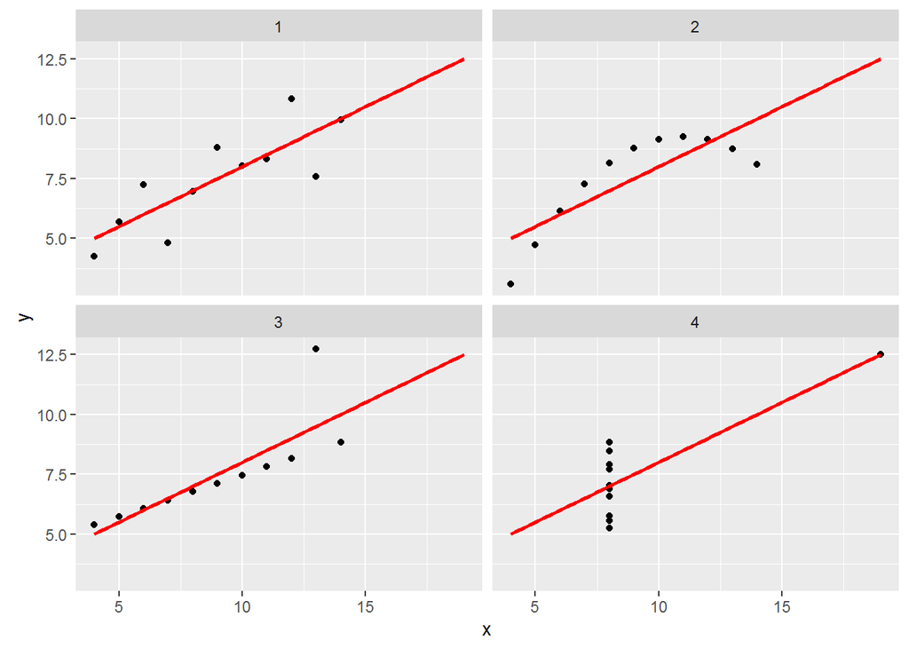

```r
library(ggplot2)
data(anscombe)

ansX <- with(anscombe, c(x1, x2, x3, x4))
ansY <- with(anscombe, c(y1, y2, y3, y4))
ansType <- rep(1:4, each=nrow(anscombe))
ansFrame <- data.frame(x=ansX, y=ansY, series=factor(ansType))

# ggplot example for Anscombe data
ggplot(ansFrame, aes(x=x, y=y)) +
    geom_point() +
    geom_smooth(method="lm", col="red", se=FALSE, fullrange=TRUE) +
    facet_wrap(~ series, nrow=2)
```

As well, the basic example code from above is useful to explore:

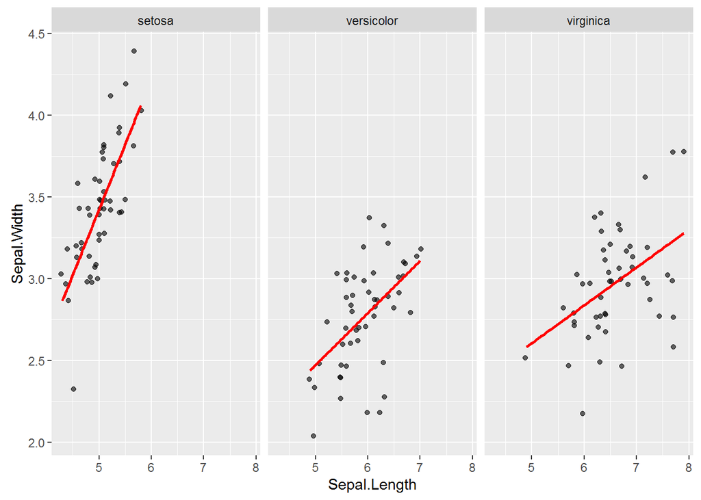

```r
data(iris)

ggplot(iris, aes(x=Sepal.Length, y=Sepal.Width)) +
    geom_jitter(alpha = 0.6) +
    facet_grid(. ~ Species) +
    stat_smooth(method = "lm", se = FALSE, col="red")
```

```r
# Explore the mtcars data frame with str()
data(mtcars)
str(mtcars)
```

```
## 'data.frame':    32 obs. of  11 variables:
##  $ mpg : num  21 21 22.8 21.4 18.7 18.1 14.3 24.4 22.8 19.2 ...
##  $ cyl : num  6 6 4 6 8 6 8 4 4 6 ...
##  $ disp: num  160 160 108 258 360 ...
##  $ hp  : num  110 110 93 110 175 105 245 62 95 123 ...
##  $ drat: num  3.9 3.9 3.85 3.08 3.15 2.76 3.21 3.69 3.92 3.92 ...
##  $ wt  : num  2.62 2.88 2.32 3.21 3.44 ...
##  $ qsec: num  16.5 17 18.6 19.4 17 ...
##  $ vs  : num  0 0 1 1 0 1 0 1 1 1 ...
##  $ am  : num  1 1 1 0 0 0 0 0 0 0 ...
##  $ gear: num  4 4 4 3 3 3 3 4 4 4 ...
##  $ carb: num  4 4 1 1 2 1 4 2 2 4 ...
```

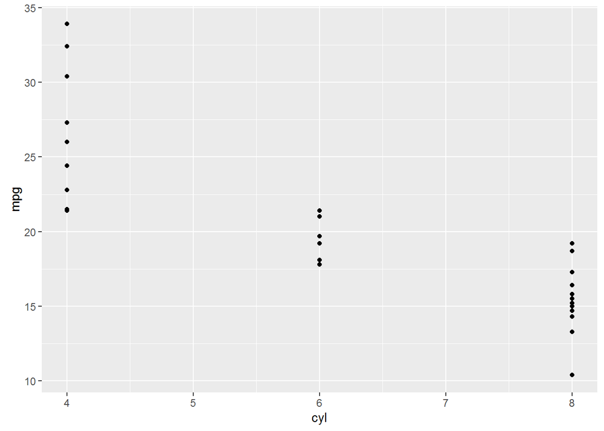

```r
# Execute the following command
ggplot(mtcars, aes(x = cyl, y = mpg)) +
  geom_point()
```

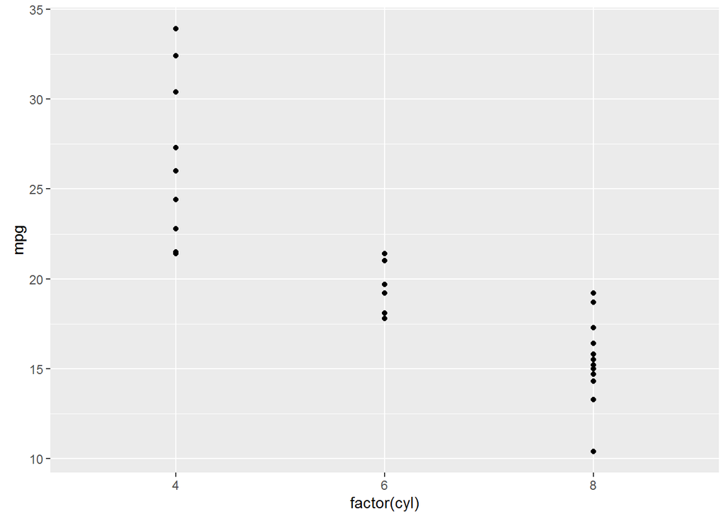

```r
# Change the command below so that cyl is treated as factor
ggplot(mtcars, aes(x = factor(cyl), y = mpg)) +
  geom_point()
```

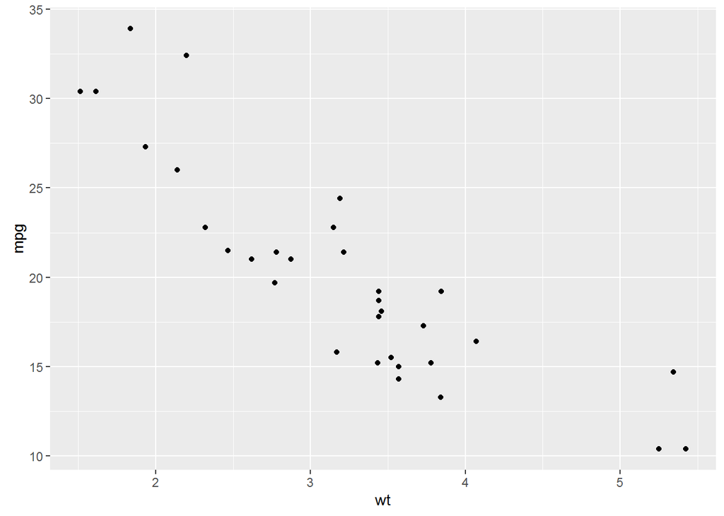

```r
# A scatter plot has been made for you
ggplot(mtcars, aes(x = wt, y = mpg)) +
  geom_point()
```

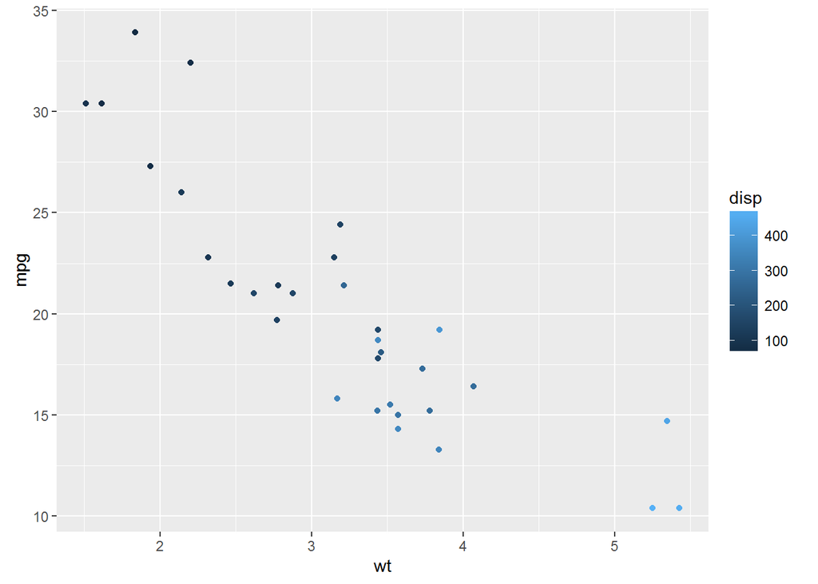

```r
# Replace ___ with the correct vector
ggplot(mtcars, aes(x = wt, y = mpg, col = disp)) +
  geom_point()
```

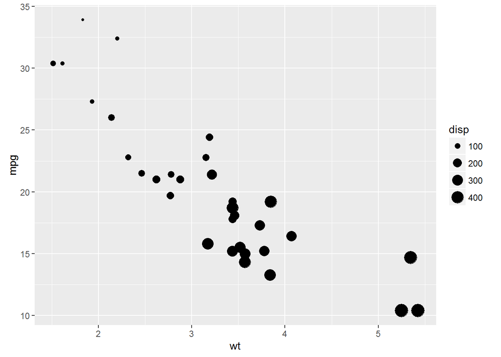

```r
# Replace ___ with the correct vector
ggplot(mtcars, aes(x = wt, y = mpg, size = disp)) +
  geom_point()
```